# notebook slides

## Etape 1 — Explorer les donnees

Avant de modeliser, il faut comprendre les donnees. L'EDA (analyse exploratoire des données) revele les distributions, les anomalies et les relations entre variables.

### 1.1 Chargement des donnees

Deux fichiers CSV fournis :

- `data/observations.csv` : 10000 lignes, 12 colonnes
- `data/parcelles.csv` : 500 lignes, 12 colonnes

```
2026-06-13 17:01:34.109 | INFO     | __main__:<module>:12 - Démarrage de l'ingestion des sources brutes.
```

```
observations : 10000 lignes, 12 colonnes
parcelles     : 500 lignes, 12 colonnes
```

### 1.2 Apercu et statistiques descriptives

Examiner shape, dtypes, valeurs manquantes par colonne, statistiques descriptives.

Objectif : profilage des données.

- Comprendre la structure des tables (dimensions, types de variables).
- Évaluer la qualité des données (identifier les valeurs manquantes, les incohérences).
- Déceler les anomalies évidentes (valeurs aberrantes ou outliers).
- Guider les futures étapes de préparation (feature engineering, nettoyage, choix des modèles).

```
=== observations ===

--- Types de colonnes ---
ObservationID                      object
ParcelleID                         object
DateObservation            datetime64[ns]
Temperature                       float64
Humidite                          float64
Pluviometrie_mm                   float64
NDVI                              float64
Capteur                            object
StadeCulture                       object
RendementEstime_t_ha              float64
RendementMoyenZone_t_ha           float64
AnomalieLabel                       int64
dtype: object

--- Valeurs manquantes ---
ObservationID                0
ParcelleID                   0
DateObservation              0
Temperature                214
Humidite                   146
Pluviometrie_mm            197
NDVI                       307
Capteur                      0
StadeCulture                 0
RendementEstime_t_ha       231
RendementMoyenZone_t_ha      0
AnomalieLabel                0
dtype: int64

--- Statistiques descriptives ---
       ObservationID ParcelleID                DateObservation  Temperature  \
count          10000      10000                          10000  9786.000000
unique         10000        500                            NaN          NaN
top        OBS000001      P0427                            NaN          NaN
freq               1         33                            NaN          NaN
mean             NaN        NaN  2025-01-01 10:29:45.334699776    16.941886
min              NaN        NaN            2024-03-01 05:51:17    -6.700000
```

[output cut: 38 more lines]

```
4     OBS000005      P0411 2024-03-30 19:54:57         12.2      62.5

   Pluviometrie_mm    NDVI      Capteur StadeCulture  RendementEstime_t_ha  \
0             14.8  0.6627       Manuel      Récolte                  2.09
1              6.8  0.4558        Drone        Levée                  4.14
2              0.3  0.6985    Satellite   Maturation                  4.05
3              3.8  0.4121  Station_Sol      Récolte                  9.39
4             10.5  0.6393    Satellite        Levée                 10.52

   RendementMoyenZone_t_ha  AnomalieLabel
0                     3.09              0
1                     3.57              0
2                     2.99              0
3                     7.70              0
4                     8.94              0
```

```
=== parcelles ===

--- Types de colonnes ---
ParcelleID            object
Exploitant            object
Email                 object
Telephone             object
NumSIRET              object
Region                object
Surface_ha           float64
TypeCulture           object
TypeSol               object
Irrigation            object
DateMiseEnCulture     object
CodePostal            object
dtype: object

--- Valeurs manquantes ---
ParcelleID            0
Exploitant           21
Email                23
Telephone            36
NumSIRET             47
Region                0
Surface_ha           17
TypeCulture           0
TypeSol               0
Irrigation            0
DateMiseEnCulture     0
CodePostal            0
dtype: int64

--- Statistiques descriptives ---
       Surface_ha
count  483.000000
mean    97.830455
std     58.862420
min     -4.560000
25%     47.275000
50%     98.270000
```

[output cut: 9 more lines]

```
4      P0005       Julien Moreau       moreau.julien@yahoo.fr

           Telephone           NumSIRET           Region  Surface_ha  \
0         0189254563  130 195 323 40495  Hauts-de-France      143.35
1     07 54 87 43 15  649 227 487 20328  Hauts-de-France      177.15
2     07 36 95 44 99  763 173 723 93227         Bretagne       92.72
3  +33 4 92 68 28 43  862 674 651 44438        Normandie       72.72
4     01 97 78 44 92  400 545 261 69470        Occitanie       53.05

  TypeCulture   TypeSol       Irrigation DateMiseEnCulture CodePostal
0       Colza  Calcaire        Aspersion        2025-04-26      62000
1       Vigne  Limoneux  Goutte-à-goutte        2024-03-25      59000
2       Vigne  Limoneux       Gravitaire        2024-03-27      XXXXX
3        Maïs  Calcaire  Goutte-à-goutte        2024-02-05      50000
4       Colza  Limoneux  Goutte-à-goutte        2025-03-05      66000
```

Analyse :

**Table observations** (10 000 lignes)

- Problème majeur de valeurs aberrantes (Outliers physiques) :
  - Temperature : Le maximum est à 79.8°C. C'est irréaliste pour de l'agriculture. Il y a un problème de capteur.
  - Humidite : Le maximum est à 148.6%. Une humidité relative ne peut pas dépasser 100%.
  - Pluviometrie_mm : Le minimum est à -10.0 mm. Une précipitation négative est impossible.
  - NDVI : Le maximum est à 2.4537. L'indice NDVI est théoriquement strict entre -1 et 1.
- Données manquantes (Missing Values) : * Toutes les variables environnementales (Temperature, Humidite, Pluviometrie_mm, NDVI) et le RendementEstime_t_ha possèdent entre 146 et 307 valeurs manquantes. Il faudra planifier une stratégie d'imputation (médiane, moyenne par classe ou interpolation).
- Déséquilibre des classes (Imbalanced Data) :
  - La moyenne de AnomalieLabel est de 0.1168, ce qui signifie qu'il y a environ 11.7% d'anomalies pour 88.3% de cas normaux. C'est un cas classique de classification déséquilibrée qu'il faudra gérer lors du build du modèle d'IA (via du rééchantillonnage ou des métriques adaptées comme le F1-score).

**Table parcelles** (500 lignes)

- Incohérence géométrique :
  - Surface_ha : Le minimum est à -4.56 ha. Une surface négative n'existe pas.
- Qualité et formatage des données textuelles :
  - CodePostal : Présence de valeurs masquées ou erronées comme "XXXXX".
  - DateMiseEnCulture : Elle est actuellement typée en object (chaîne de caractères). Il faudra la convertir en datetime64 pour pouvoir l'exploiter proprement.
- Données manquantes et RGPD :
  - Il manque des informations de contact (Exploitant, Email, Telephone) et administratives (NumSIRET). Si ces données n'ont pas d'intérêt prédictif pour l'IA, elles devront probablement être écartées (ou anonymisées).

**Synthèse**

En résumé : Cette étape met en évidence la nécessité absolue d'une phase rigoureuse de Data Cleaning (filtrage des valeurs aberrantes, gestion des valeurs manquantes, conversion des types) avant d'entamer la fusion (merge) des deux tables sur la clé ParcelleID et l'entraînement du modèle d'IA.

### 1.3 Distribution de la variable cible

Le desequilibre de classes influence le choix des metriques et de la strategie d'entrainement. Un modele naif qui predit toujours "Normal" aurait ~88% d'accuracy mais serait inutile.

Dans le dataset :

la variable cible est déjà définie : AnomalieLabel

0 = situation normale 1 = anomalie

**Objectif** : comprendre la répartition de la variable que le modèle d'IA devra prédire (AnomalieLabel). Elle permet de :

- Vérifier l'équilibre des classes (comparer le nombre de situations normales vs anomalies).
- Anticiper les biais du modèle (un modèle a tendance à mieux apprendre la classe majoritaire).
- Définir la stratégie de modélisation (choix des métriques d'évaluation, techniques de rééchantillonnage, méthode de découpage des données).

```
Distribution de AnomalieLabel :
AnomalieLabel
0    8832
1    1168
Name: count, dtype: int64

Taux de anomalie : 11.7%
```

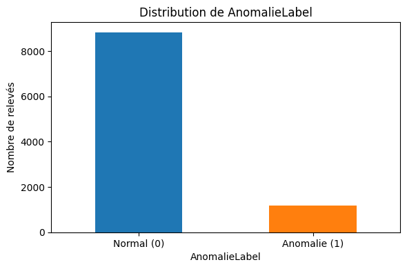

Analyse : 88,3% de situations normales (0) et 11,7% d'anomalies (1) :

- Déséquilibre des classes significatif (Class Imbalance) : Le modèle aura naturellement moins d'exemples pour apprendre à identifier une anomalie.
- Piège de la métrique d'exactitude (Accuracy Trap) : On ne pourras pas utiliser l'Unité de mesure Accuracy pour évaluer l'IA. Un modèle naïf qui prédirait "0" (normal) tout le temps aurait une exactitude de 88,3%, tout en étant totalement inutile puisqu'il raterait 100% des anomalies.
- Sélection de métriques adaptées : orienter le choix des métriques vers le Rappel (Recall : pour ne rater aucune anomalie), la Précision (pour éviter les fausses alertes) et le F1-Score (le compromis entre les deux).
- Impact sur la validation (Stratification) : Lors de la séparation des données en ensembles d'entraînement et de test (train_test_split), il sera obligatoire d'utiliser l'argument stratify=y (ou un StratifiedKFold). Cela garantit que la proportion de 11,7% d'anomalies soit préservée dans chaque bloc de données.

**Synthèse** :

- En résumé : Le dataset présente un déséquilibre de classes (11,7% d'anomalies). Cette observation impose l'abandon de l'Accuracy au profit du F1-Score / Rappel pour l'évaluation de l'IA, et nécessite l'utilisation d'un découpage stratifié des données lors de la phase d'entraînement.

### 1.4 Visualisations

Objectif : passer d'une compréhension mathématique à une compréhension intuitive et visuelle des données. Cartographier les valeurs aberrantes, Analyser la forme des distributions et de repérer graphiquement quelles variables (comme la température ou le NDVI) discriminent le mieux les anomalies.

#### 1. Distributions des variables numériques (Histogrammes)

- **Réalisation ML** : Une boucle `for` sur `num_cols` exploitant `ax.hist(observations[col].dropna(), bins=30)` pour isoler et afficher la distribution de fréquence de chaque capteur ou indicateur numérique.
- **Ce qu'on cherche à voir** : La forme de la distribution de chaque variable (symétrique, normale, asymétrique, bimodale) ainsi que la présence potentielle de valeurs aberrantes extrêmes (*outliers*). On observe également la disparité des échelles de grandeur entre les variables.
- **Réflexion architecturale / Métier** : Cette analyse dicte les choix techniques du pipeline de feature engineering. Si les distributions présentent une forte asymétrie (*skewness*) ou des échelles hétérogènes (ex: une variable entre 0 et 1, une autre entre 100 et 1000), certains algorithmes (comme les SVM, la régression logistique ou les réseaux de neurones) seront fortement pénalisés. L'architecture de préparation des données devra donc inclure des étapes de normalisation ou de standardisation robustes (ex: `StandardScaler` ou `RobustScaler` en présence d'outliers).

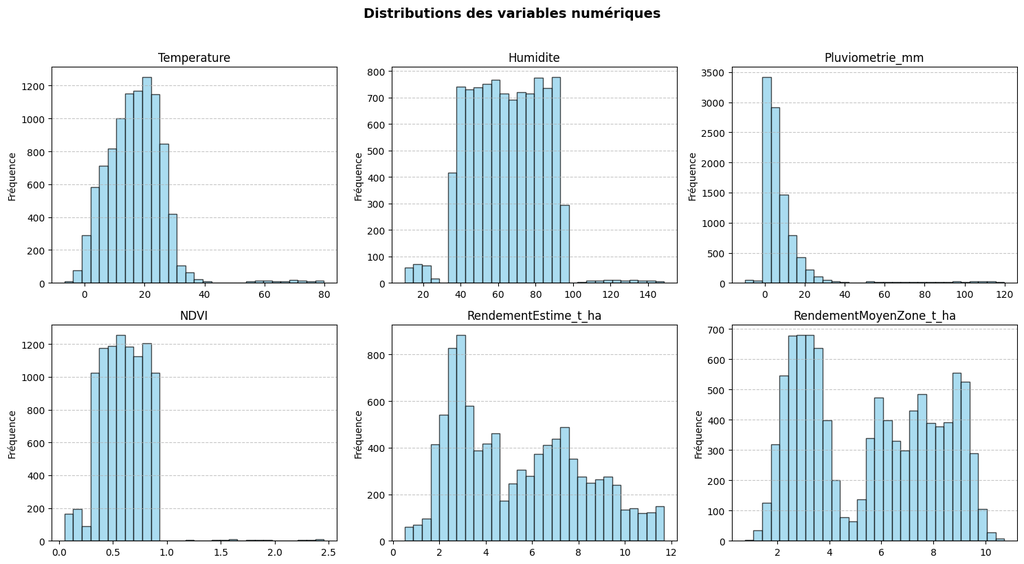

Analyse :

- Temperature, Humidite, NDVI : On voit très clairement le bloc principal des données s'arrêter net (ex: à 100% pour l'humidité, à 1.0 pour le NDVI), suivi d'un grand vide, puis de petites barres isolées tout à fait à droite. C'est la signature visuelle indiscutable d'erreurs de mesure (outliers).
- Pluviometrie_mm : La distribution est fortement asymétrique à droite (right-skewed). La majorité des jours ont une pluviométrie faible (entre 0 et 20 mm), ce qui est normal, mais la présence de valeurs allant jusqu'à 120 mm (et une barre sous le 0) confirme qu'un traitement des valeurs extrêmes est requis.
- Les Rendements (Estimé et Moyen) : La présence de deux sommets clairs (autour de 3 et 8 t/ha) prouve que le modèle de Machine Learning devra impérativement s'appuyer sur des variables catégorielles comme le TypeCulture ou le StadeCulture pour segmenter ses prédictions.
- Réflexion Métier (Agronomie) :
  - Les distributions des rendements (RendementEstime et RendementMoyenZone) sont bimodales. D'un point de vue métier, cela s'explique par la coexistence de cultures aux rendements totalement différents (par exemple, la vigne produit moins de tonnes à l'hectare que le maïs).
  - Les "îlots" isolés à l'extrême droite de la température, de l'humidité ou du NDVI confirment des pannes matérielles ou des erreurs de transmission des capteurs.
- Réflexion Architecturale (Pipeline de données) :
  - Normalisation : La forte asymétrie de la pluviométrie ou du NDVI montre qu'un simple StandardScaler (qui suppose une loi normale) sera moins efficace. Il faudra envisager un RobustScaler ou une transformation logarithmique.
  - Nettoyage automatique : L'architecture du pipeline devra inclure une étape de clipping (écrêtage) ou de suppression des lignes contenant ces valeurs aberrantes avant d'alimenter l'IA.

**Synthèse** :

- En résumé : Ces histogrammes confirment visuellement que les valeurs aberrantes (capteurs défaillants) forment des "bruits" isolés faciles à filtrer. De plus, la nature bimodale des rendements indique graphiquement que les données cachent deux sous-populations (les types de cultures), une information cruciale pour orienter le choix du futur modèle d'IA.

#### 2. Matrice de corrélation

- **Réalisation ML** : `sns.heatmap(observations[cols_to_corr].corr(), annot=True, fmt=".2f", cmap="RdYlBu_r", vmin=-1, vmax=1)` en intégrant explicitement la variable cible `AnomalieLabel`.
- **Ce qu'on cherche à voir** :
  - Identifier la multicolonnalité : Repérer si des variables explicatives sont fortement corrélées entre elles (ce qui fait doublon et perturbe certains modèles).
  - Déceler les signaux prédictifs : Repérer quelles variables ont la plus forte relation linéaire avec la variable cible AnomalieLabel afin d'anticiper les fonctionnalités clés (features) pour l'IA.
- **Réflexion architecturale / Métier** : D'un point de vue architectural, détecter des variables fortement corrélées entre elles (ex: > 0.85) signale une redondance d'information. Pour optimiser les performances du modèle et limiter le risque de surapprentissage (*overfitting*), nous pourrons envisager une sélection de variables (*Feature Selection*) ou une réduction de dimension. Réduire le nombre de features permet d'alléger la charge de calcul du pipeline en production et de diminuer le coût de stockage ou de bande passante si les données proviennent de capteurs IoT distants.

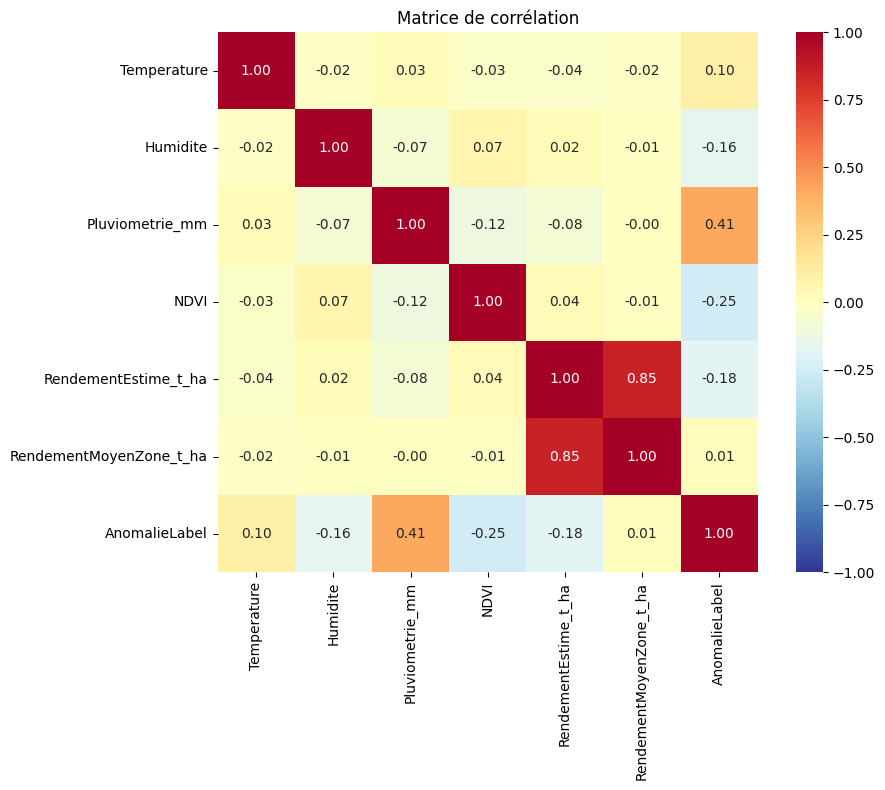

Analyse :

- Les deux meilleurs prédicateurs linéaires : Pluviometrie_mm (0.41) et NDVI (-0.25) sont les variables qui influencent le plus positivement et négativement l'apparition d'une anomalie.
- Le doublon des rendements : La relation à 0.85 entre les deux variables de rendement confirme qu'elles partagent la même information à 85%.
- Des relations globalement faibles/faibles ou non-linéaires : La Temperature (0.10) et l' Humidite (-0.16) semblent peu corrélées linéairement à l'anomalie. Cela indique qu'un modèle linéaire simple aura du mal à capter les règles subtiles, renforçant l'intérêt d'utiliser des modèles non-linéaires (arbres de décision, SVM ou réseaux de neurones) pour l'IA.
- Réflexion Métier (Agronomie) :
  - La corrélation négative entre le NDVI et AnomalieLabel (-0.25) est logique : plus l'indice de végétation baisse, plus la probabilité d'avoir une anomalie (maladie, sécheresse) augmente.
  - La corrélation positive avec la Pluviometrie_mm (0.41) indique que les fortes pluies (ou les valeurs aberrantes à 120 mm vues à l'étape précédente) sont fortement liées aux signalements d'anomalies.
- Réflexion Architecturale (Pipeline IA) :
  - Alerte Rouge sur la Multicolonnalité : RendementEstime_t_ha et RendementMoyenZone_t_ha ont une corrélation très élevée de 0.85.
  - Conséquence sur l'architecture : Conserver ces deux variables va biaiser les modèles linéaires (comme la Régression Logistique). Deux choix architecturaux payants sont possibles : soit en supprimer une des deux lors du Feature Selection, soit orienter l'architecture vers des modèles d'arbres (Random Forest, XGBoost) qui gèrent nativement et sans problème cette redondance.

**Synthèse** :

En résumé : La heatmap révèle une forte multicolonnalité (0.85) entre les deux variables de rendement, imposant un arbitrage architectural (suppression d'une variable ou choix d'un modèle d'arbre). Elle isole également la pluviométrie et le NDVI comme les moteurs principaux des anomalies, tout en suggérant l'échec des modèles purement linéaires pour ce dataset.

#### 3. Distributions des variables numériques par statut d'anomalie (Boxplots)

- **Réalisation ML** : `sns.boxplot(data=observations, x="AnomalieLabel", y=col)` décliné sur l'ensemble des colonnes numériques avec une coloration bicolore distinctive (Normal vs Anomalie).
- **Ce qu'on cherche à voir** : Évaluer le pouvoir séparateur de chaque variable numérique. On cherche à voir si la distribution (médiane, écart-interquartile) d'une métrique change de manière significative lorsque la parcelle bascule en anomalie (`1`) par rapport à une situation normale (`0`).
- **Réflexion architecturale / Métier** : Cette visualisation permet de valider la cohérence agronomique et métier des données avec les experts du domaine (ex: vérifier qu'une baisse d'humidité ou une anomalie thermique se traduit bien par un comportement graphique distinct). Si le boxplot met en évidence que les anomalies sont déclenchées par des seuils critiques ou des valeurs extrêmes, cela justifie l'intégration d'une couche logicielle de validation de données (type *Data Quality Guards*) pour intercepter les anomalies évidentes avant même de solliciter l'inférence du modèle ML.

[output not shown]

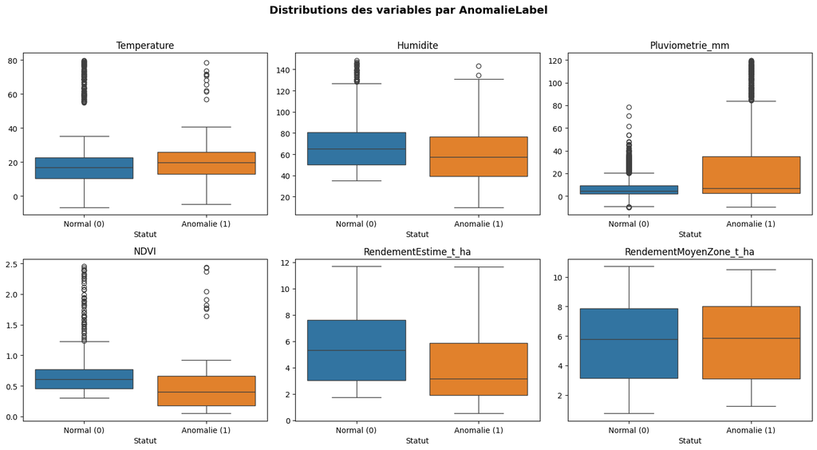

Analyse :

- Les variables clés pour l'IA (Top Features) :
  - Pluviometrie_mm : signal le plus flagrant. En situation normale, la pluie est très basse et stable (boîte écrasée proche de 0). En cas d'anomalie, la boîte s'étire vers le haut avec une quantité de pluie et des outliers très élevés. Les anomalies sont fortement corrélées à des événements de saturation en eau (inondations / fortes pluies).
  - NDVI : La boîte orange (Anomalie) est globalement plus basse que la bleue (Normal). Un NDVI bas (perte de couleur verte de la végétation) est un excellent indicateur d'anomalie sur la parcelle.
  - RendementEstime_t_ha : Le rendement estimé est visiblement impacté à la baisse (médiane plus basse) en cas d'anomalie.
- Les variables neutres : La Temperature et surtout le RendementMoyenZone_t_ha montrent des boîtes très superposées. Prises seules, elles ne permettront pas à l'IA de deviner s'il y a une anomalie.
- Réflexion Métier (Agronomie vs Technique) :
  - Le valeurs aberrantes extrêmes (l'humidité > 120 %, le NDVI > 2, la température > 60 °C) apparaissent massivement dans la classe Normal (0) !
  - Conclusion métier : Le label AnomalieLabel désigne des anomalies agronomiques (maladies, stress hydrique sévère) et non des pannes de capteurs.
- Réflexion Architecturale (Data Pipeline) :
  - Nettoyage obligatoire en amont : laisser ces pannes de capteurs (les points isolés tout en haut du statut Normal), va totalement perturbé le modèle d'IA. Il faut concevoir un bloc de pré-traitement qui filtre ces anomalies techniques avant que le modèle ne cherche à apprendre les anomalies métiers.
  - Sélection de variables (Feature Selection) : alléger l'architecture en excluant ou en baissant le poids de RendementMoyenZone_t_ha, car sa distribution est rigoureusement identique pour les deux classes. Elle n'apporte aucune information utile au modèle.

**Synthèse** :

En résumé : Ces boxplots démontrent que la Pluviometrie_mm et le NDVI sont les variables les plus discriminantes pour l'IA. De plus, ils révèlent une dissociation critique pour l'architecture du projet : les pannes de capteurs (valeurs physiques impossibles) polluent la classe "Normal", imposant la création d'un pipeline de nettoyage technique avant de pouvoir modéliser l'anomalie agricole.

#### 4. Taux d'anomalie moyen par type de Capteur

- **Réalisation ML** : `observations.groupby("Capteur")["AnomalieLabel"].mean() * 100` affiché sous forme de diagramme en barres trié par ordre décroissant.
- **Ce qu'on cherche à voir** :
  - Si le moyen de collecte des données (Manuel, Station Sol, Satellite, Drone) influence le taux d'anomalies détectées.
  - S'il existe un biais d'acquisition (par exemple, est-ce que les drones détectent plus d'anomalies parce qu'on ne les fait voler que lorsque l'on suspecte un problème ?).
- **Réflexion architecturale / Métier (Gestion des Biais)** : Cette analyse est fondamentale pour l'audit éthique et la conformité réglementaire (ex: exigences de l'AI Act). Si un capteur de type "Manuel" affiche un taux d'anomalie drastiquement supérieur aux capteurs automatisés, cela révèle un **biais de déclaration**. Les opérateurs terrain ont tendance à ne consigner un rapport manuel que lorsqu'ils constatent visuellement un problème. Le modèle risque donc d'associer la source "Manuel" à une anomalie de cause à effet. L'architecture du pipeline devra atténuer ce biais, par exemple en évaluant l'opportunité de supprimer la feature "Capteur" lors de l'entraînement pour éviter des prédictions discriminatoires ou faussées.

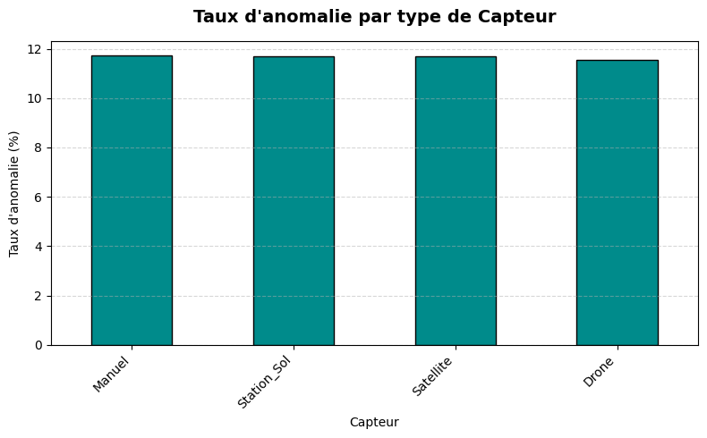

Analyse :

- Indépendance statistique : La variable AnomalieLabel est statistiquement indépendante de la variable Capteur.
  - Confirmation du taux global : On retrouve pour chaque barre le taux de 11,7 % d'anomalies identifié à l'étape 1.3. Le déséquilibre des classes est donc le même, peu importe le capteur utilisé.
  - Absence de biais technique : Aucun capteur n'est sur-représenté ou sous-représenté en termes d'anomalies, ce qui valide la cohérence globale du jeu de données fourni.
- Réflexion Métier (IoT / Agronomie) :
  - Le graphique montre un profil parfaitement plat. Que la donnée vienne d'un satellite, d'un relevé manuel, d'un drone ou d'une station au sol, le taux d'anomalie reste strictement le même (~11,7 %). Cela prouve la neutralité du protocole de collecte : les anomalies agronomiques sont réparties de manière homogène dans toutes les sources de données.
- Réflexion Architecturale (Feature Selection) :
  - Une variable inutile pour l'IA : En data science, une variable qui se distribue de la même manière pour toutes ses modalités n'apporte aucune information discriminante à un algorithme.
  - Action architecturale : la colonne Capteur pourra être exclue du dataset final avant l'entraînement du modèle. Cela permet d'alléger l'architecture en réduisant la dimensionnalité du modèle (pas besoin de créer 4 colonnes de One-Hot Encoding inutiles).

**Synthèse** :

En résumé : Ce graphique démontre que le type de capteur n'a aucune influence sur le taux d'anomalie, qui reste figé à ~11,7 %. D'un point de vue architectural, la variable Capteur n'ayant aucun pouvoir prédictif, elle pourra être écartée du pipeline de modélisation pour simplifier et optimiser l'IA.

#### 5. Évolution mensuelle du taux d'anomalie

- **Réalisation ML** : Conversion de la colonne temporelle puis rééchantillonnage à la maille mensuelle via `.resample("ME").mean() * 100`, matérialisé par un graphique linéaire (`kind="line"`).
- **Ce qu'on cherche à voir** : Déceler la présence de tendances macroscopiques, de variations saisonnières ou de pics temporels spécifiques dans l'apparition des anomalies tout au long de l'année.
- **Réflexion architecturale / Métier (MLOps & Drift)** : Le contexte agricole étant soumis aux cycles des saisons, le comportement des données va inévitablement évoluer au cours du temps. L'identification d'une saisonnalité impose des contraintes fortes sur l'architecture de production (MLOps) :
  1. Conception de features temporelles cycliques (ex: encodage sinus/cosinus du mois).
  2. Planification d'une stratégie de surveillance du *Data Drift* et du *Concept Drift*.
  3. Automatisation du réentraînement du modèle (ex: à chaque fin de campagne agricole) pour éviter le vieillissement et la perte de précision des prédictions.

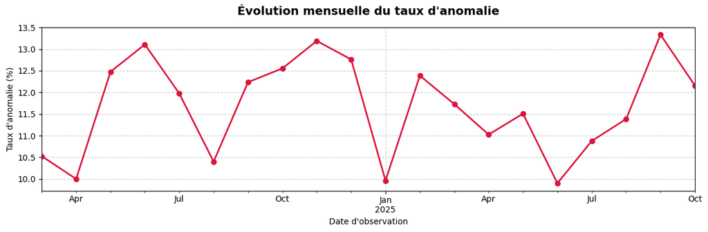

Analyse :

- Attention à l'effet de loupe (Échelle de l'axe Y) : Visuellement, la courbe semble très accidentée, mais en regardant attentivement l'axe des ordonnées : le taux d'anomalie oscille uniquement entre 10% et 13,4%. L'apparition des anomalies reste donc globalement stable et maîtrisée tout au long de l'année autour de la moyenne de 11,7%.
- Présence d'une micro-saisonnalité : On remarque des creux réguliers (autour de janvier et d'avril) et des pics récurrents. Cela confirme que le facteur temporel cache des signaux faibles mais réels que l'IA pourra exploiter grâce aux fonctionnalités temporelles (time features).
- Réflexion Métier (Agronomie) : L'agriculture vit au rythme des saisons. Les fluctuations observées coïncident logiquement avec les cycles de culture (ex: les périodes de maturation ou de récolte où les parcelles sont plus sensibles) et les variations climatiques annuelles.
- Réflexion Architecturale (Stratégie de Validation de l'IA) :
  - Alerte "Data Leakage" (Fuite de données) : Face à des données étalées dans le temps (2024 à 2025), un découpage aléatoire classique (train_test_split) est une mauvaise pratique. Le modèle risquerait d'utiliser des données du "futur" pour prédire le "passé".
  - Action architecturale : Pour l'évaluation du modèle, il faut appliquer une stratégie de Time-Based Split (par exemple, entraîner l'IA sur l'année 2024 et la tester sur l'année 2025) ou utiliser une validation croisée temporelle (TimeSeriesSplit).
  - Feature Engineering : Ce graphique justifie la création de nouvelles variables issues de la date : Mois, Saison, ou Jour_de_l_annee pour aider le modèle à capter ces variations.

**Synthèse** :

En résumé : L'évolution mensuelle révèle que le taux d'anomalie fluctue légèrement (entre 10% et 13,4%) selon les périodes de l'année, confirmant une dynamique saisonnière propre à l'agriculture. D'un point de vue architectural, cette dépendance temporelle impose le choix d'un découpage chronologique des données (Time-Based Split) pour l'entraînement de l'IA afin d'éviter tout biais de prédiction.

#### 6. Heatmap des valeurs manquantes (Variables Numériques)

- **Réalisation ML** : `sns.heatmap(observations[num_cols].isnull(), cbar=True, yticklabels=False, cmap="viridis")` où la couleur jaune isole visuellement les entrées `NaN`.
- **Ce qu'on cherche à voir** : Visualiser la structure, la concentration et la distribution des valeurs manquantes. Sont-elles distribuées de façon totalement aléatoire ou apparaissent-elles sous forme de blocs compacts ?
- **Réflexion architecturale / Métier (Robustesse et Tolérance aux pannes)** : Si les données manquantes apparaissent par blocs, cela traduit des pannes matérielles synchrones ou des pertes temporaires de réseau IoT sur le terrain. Face à cette réalité métier, l'architecture logicielle du pipeline d'ingestion ne peut pas se contenter d'une suppression brute des lignes manquantes (sous peine de perdre trop d'informations). Elle doit impérativement intégrer une stratégie d'imputation robuste et résiliente en production (ex: *Forward Fill* temporel ou imputation par *K-NN Imputer*) pour garantir la continuité des prédictions, même en cas de défaillance partielle des capteurs.

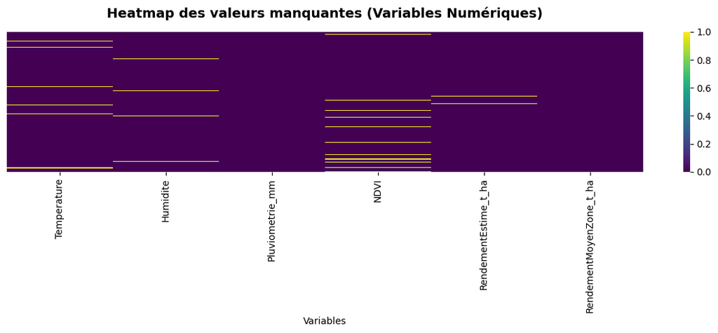

Analyse :

- Indépendance des pannes : La dispersion des traits jaunes confirme visuellement l'indépendance des pertes de données entre la température, l'humidité et le NDVI.
  - Intégrité de la zone : La colonne RendementMoyenZone_t_ha est totalement violette, confirmant qu'il n'y a aucune perte d'information sur les données macroéconomiques/historiques de la zone.
  - Rapport de volume gérable : Le grand volume de violet (données présentes) face aux lignes jaunes très fines confirme que le dataset reste excellent et tout à fait exploitable pour l'IA après une légère phase de correction.
- Réflexion Métier (IoT / Maintenance des capteurs) : Les lignes jaunes (valeurs manquantes) apparaissent de manière totalement isolée et dispersée. Elles ne s'alignent pas horizontalement sur l'ensemble des colonnes. Cela prouve qu'il ne s'agit pas d'une coupure d'électricité générale d'une station ou d'un bug réseau global, mais plutôt de micro-coupures ou d'anomalies de lecture spécifiques à chaque capteur individuel.
- Réflexion Architecturale (Stratégie d'Imputation dans le Pipeline) :
  - Pas de suppression de lignes : Comme les manques ne sont pas synchronisés, supprimer les lignes avec des NaN reviendrait à amputer le dataset de près de 10% de sa taille globale sans raison valable.
  - Choix de l'algorithme d'imputation : Le pattern étant de type MCAR (Missing Completely At Random), il faut appliquer une stratégie d'imputation simple mais robuste, comme un SimpleImputer basé sur la médiane (pour ne pas subir l'influence des valeurs aberrantes vues précédemment) ou un calcul de moyenne groupé par classe (StadeCulture), voire un algorithme plus avancé comme un KNNImputer.

**Synthèse**

En résumé : La heatmap démontre que les valeurs manquantes sont réparties de manière aléatoire et indépendante d'un capteur à l'autre. D'un point de vue architectural, cela exclut la suppression brute des lignes au profit d'une stratégie d'imputation par la médiane (ou par un KNN Imputer), préservant ainsi l'intégrité et le volume du dataset d'entraînement.

### 1.5 Audit de qualite

Recenser tous les problemes de qualite avec le nombre d'occurrences et l'impact sur la modelisation.

```
============================================================
                RAPPORT D'AUDIT DE QUALITÉ
============================================================
1. Valeurs Manquantes NDVI : 307 occurrences (3.07%)
2. Manques Physiques Cumulés (Temp/Hum/Pluvio) : 539 lignes (5.39%)
3. Aberrations Physiques NDVI (Hors [-1, 1]) : 68 occurrences (0.68%)
4. Pluviométries Négatives (Erreurs IoT) : 90 occurrences (0.90%)
5. Outliers Thermiques (>55°C ou <-15°C) : 108 occurrences (1.08%)
6. Codes Postaux Invalides/Masqués ('XXXXX') : 18 parcelles (3.60%)
7. Surfaces de Parcelles Invalides (NaN/<=0) : 28 parcelles (5.60%)
8. Enregistrements PII Exposés (Email/Tel/SIRET) : 477 / 464 / 453 lignes (95.40%)
============================================================
```

#### Réflexion Architecturale : Impact sur la Modélisation

Ce rapport d'audit quantifie précisément les vulnérabilités techniques et juridiques des fichiers sources (parcelles.csv et observations.csv) afin de justifier scientifiquement les choix de nettoyage de l'étape suivante.

##### Matrice de diagnostic et impacts sur la modélisation

| # | Anomalie constatée & Quantification | Cause racine probable | Impact critique sur l'IA & l'Architecture |
| --- | --- | --- | --- |
| 1 | Manques NDVI • 307 occurrences (3,07 %) | Environnementale : Couverture nuageuse bloquant la détection spectrale. | Incompatibilité algorithmique : Bloque la convergence des modèles basés sur des distances (SVM) ou des coefficients linéaires. |
| 2 | Manques Physiques Cumulés • 539 lignes (5,39 %) | Matérielle : Micro-coupures réseau ou pertes d'alimentation des stations IoT au sol. | Perte de signal synchrone : Risque de suppression de lignes représentatives si aucune stratégie d'imputation n'est menée. |
| 3 | Aberrations NDVI (Hors [−1,1]) • 68 occurrences (0,68 %) | Logicielle : Bug de sérialisation ou d'encodage lors du transfert des paquets de données. | Distorsion des gradients : Des valeurs massives écrasent le poids des autres variables lors de l'entraînement. |
| 4 | Pluviométries Négatives • 90 occurrences (0,90 %) | Matérielle : Mauvais calibrage du "zéro logique" des capteurs après une période sèche. | Shortcut Learning / Biais : L'IA risque de modéliser la signature de la panne matérielle plutôt que l'anomalie agronomique réelle. |
| 5 | Outliers Thermiques (>55∘C / <−15∘C) • 108 occurrences (1,08 %) | Matérielle : Surchauffe locale du boîtier du capteur ou anomalie de lecture. | Bruit algorithmique : Fausse la distribution de la variable de température et décale les moyennes globales. |
| 6 | Anomalies Parcelles (CP 'XXXXX' & Surfaces ≤0) • 18 CP (3,60 %) / 28 Surfaces (5,60 %) | Humaine : Saisie manuelle erronée ou omission volontaire par souci de confidentialité. | Rupture géomarketing & Feature Engineering : Impossible de regrouper par climat zonal ou de calculer le rendement/hectare. |
| 7 | Exposition de données PII en clair • 95,40 % des fiches exploitants affectées | Gouvernance : Ingestion brute de fichiers CRM sans couche de sécurité préalable. | Data Leakage de sécurité : Non-conformité critique avec le RGPD et l'AI Act. Risque juridique majeur si stocké dans les logs ML. |

**Synthèse de l'Audit** : Le dataset possède une excellente base globale (plus de 94 % de données valides sur la météo). Cependant, la présence simultanée de PII, de valeurs hors bornes et de données manquantes exclut toute suppression brute de lignes au profit d'un pipeline de remédiation strict (imputation, filtrage et anonymisation).

### 1.6 Reflexion architecturale - Ingestion des données

Pour répondre au besoin d'intégration et d'extensibilité de la coopérative (arrivée future de prévisions météo ou d'imagerie satellite brute), l'architecture technique repose sur le **pattern ELT (Extract, Load, Transform)**.

#### 1. Cartographie et nature des flux

L'architecture isole l'extraction du chargement pour traiter de manière asynchrone l'hétérogénéité des sources :

- Flux Batch (Fichiers/APIs) : Utilisé pour le référentiel des parcelles (ponctuel), les relevés de drones/satellites (périodique) et les saisies manuelles (hebdomadaire).
- Flux Streaming / Micro-batch : Dédié aux stations au sol pour capturer les relevés météo de manière continue.

#### 2. Organisation logique du traitement (Les étapes du "T")

Une fois les données chargées telles quelles à l'état brut dans l'espace de stockage (garantissant la traçabilité complète), trois phases logiques de transformation s'exécutent en amont de la modélisation :

- La Couche Sécurité & RGPD (Masquage PII) : Traitement prioritaire dès l'entrée des parcelles. Les colonnes Exploitant, Email, Telephone et NumSIRET sont extraites, chiffrées et isolées dans un coffre-fort numérique externe. Dans le pipeline d'apprentissage, l'identité est remplacée par un jeton technique anonyme (ExploitantID).
- La Couche de Nettoyage et Robustesse : Rectification des erreurs physiques identifiées lors de l'audit (1.5). Cette couche gère l'imputation des valeurs manquantes par la médiane (calculée par type de culture et stade phénologique), applique un écrêtage sur le NDVI (maintien strict dans l'intervalle [−1,1]), et ramène à zéro les pluviométries négatives.
- La Couche Feature Store (Prête pour l'IA) : Réalisation de la jointure logique entre les tables nettoyées. C'est ici que sont appliqués le feature engineering, la sélection finale des variables (exclusion de la colonne Capteur et arbitrage de la forte corrélation entre les rendements), et l'encodage.

## Etape 2 — Preparer les donnees et questionner le traitement ethique

La qualite de la preparation conditionne directement la performance du modele. Chaque choix (imputation, encodage, features derivees) doit etre justifie. En parallele, les donnees personnelles posent des questions ethiques specifiques.

### 2.1 Nettoyage des donnees

#### A. Données Agronomiques & Végétales (NDVI)

##### Aberrations Physiques du NDVI (Hors [−1,1])

Pourquoi c'est pertinent de nettoyer : Mathématiquement, le NDVI est un ratio normalisé strictement borné entre -1 et 1. Une valeur hors de ces bornes (ex: >1 ou >100) traduit un bug de sérialisation logicielle ou une corruption du paquet de données lors du transfert. Laisser ces valeurs écraserait le poids des autres variables et fausserait les modèles sensibles à l'échelle (régressions, réseaux de neurones).

Impact du nettoyage :

- Conversion en NaN pour centraliser le traitement lors de l'imputation (2.2).
- Élimination des valeurs extrêmes artificielles qui détruisent la convergence de la descente de gradient.
- Garantie d'un signal agronomique mathématiquement valide avant modélisation.

#### B. Données Météorologiques & Capteurs (Observations)

##### Pluviométries Négatives et Valeurs Manquantes

Pourquoi c'est pertinent de nettoyer : Une pluviométrie négative est une impossibilité physique induite par un déréglage du pluviomètre. Remplacer les valeurs négatives et les NaN par 0.0 repose sur l'hypothèse métier que l'absence de signal valide ou de relevé correspond par défaut à une absence de précipitations.

Impact du nettoyage :

- Redressement immédiat des anomalies matérielles des capteurs IoT au sol.
- Suppression complète et définitive des valeurs manquantes sur cette colonne sans perte de lignes.
- Évite que le modèle n'apprenne un biais de raccourci (Shortcut Learning) en associant une valeur négative à une panne spécifique plutôt qu'à une réalité agricole.

##### Anomalies Thermiques Extrêmes (Hors [−15∘C,55∘C])

Pourquoi c'est pertinent de nettoyer : Les températures >55∘C ou <−15∘C détectées lors de l'audit sont hors des réalités climatiques régionales de la campagne. Elles signalent des surchauffes locales du boîtier du capteur exposé en plein soleil ou des pannes de batterie. Garder ces données injecterait un bruit massif capable de masquer les vrais signaux de détresse thermique ou hydrique des plantes.

Impact du nettoyage :

- Neutralisation des données IoT corrompues en les transformant en NaN.
- Stabilisation de la variance et de la distribution statistique de la variable Temperature.

#### C. Référentiel Géographique (Parcelles)

##### Codes Postaux Invalides ('XXXXX')

Pourquoi c'est pertinent de nettoyer : La chaîne de caractères 'XXXXX' résulte d'une omission volontaire ou d'une erreur de saisie humaine. Si elle n'est pas nettoyée, les algorithmes d'encodage (comme le Target Encoding ou le One-Hot Encoding) créeront une catégorie géographique artificielle qui n'a aucun sens climatique ou régional.

Impact du nettoyage :

- Remplacement par NaN pour formaliser proprement l'absence d'information géographique.

##### Surfaces de Parcelles Invalides (≤0 ou NaN)

Pourquoi c'est pertinent de nettoyer : Une surface négative ou nulle est une aberration administrative humaine. La surface étant la variable pivot pour le calcul des indicateurs de performance clés (comme le rendement total estimé à l'hectare), une valeur fausse corromprait l'ensemble des fonctionnalités créées par la suite.

Impact du nettoyage :

- Transformation des valeurs ≤0 en NaN, suivie d'un redressement par la médiane de la Region correspondante.
- Préservation de l'enregistrement de la parcelle (pas de suppression de ligne) tout en lui réaffectant une taille cohérente avec la typologie agricole locale.
- Sécurisation et fiabilisation des futurs calculs agronomiques du Feature Engineering (2.4).

#### D. Cohérence Structurelle (Doublons & Intégrité Relationnelle)

##### Doublons Exacts et Observations Orphelines

Pourquoi c'est pertinent de nettoyer : Les doublons de lignes provoquent un sur-apprentissage artificiel (overfitting) en répétant les mêmes informations dans le jeu d'entraînement et de test. De leur côté, les observations orphelines (qui pointent vers un ParcelleID inconnu dans le catalogue) brisent la logique relationnelle et provoquent des erreurs majeures lors de la jointure des tables.

Impact du nettoyage :

- Garantie de l'étanchéité et de l'intégrité relationnelle entre les fichiers observations.csv et parcelles.csv.
- Validation préventive du pipeline (le script confirmant 0 doublon et 0 orphelin, ce qui atteste de la bonne santé structurelle des bases de données de la coopérative).
- Sécurisation absolue de la jointure de données à venir (2.3).

```
[PIPELINE] Étape 2.1 : Coercition et alignement des lois physiques...
-> Observations - Doublons supprimés : 0
-> Parcelles - Doublons supprimés : 0
-> Observations orphelines supprimées (ParcelleID inconnu) : 0
-> Parcelles sans relevés supprimées : 0

Dataset Observations apres nettoyage : (10000, 12)
Observations - Valeurs manquantes restantes :
Temperature                322
Humidite                   146
Pluviometrie_mm              0
NDVI                       375
RendementEstime_t_ha       231
RendementMoyenZone_t_ha      0
AnomalieLabel                0
dtype: int64

Dataset Parcelles apres nettoyage : (500, 12)
Parcelles - Valeurs manquantes restantes :
Surface_ha    0
dtype: int64
```

### 2.2 Imputation des valeurs manquantes

L'objectif de cette étape est de combler les valeurs manquantes (manquements natifs ou générés par le filtrage physique de l'étape 2.1) en choisissant la stratégie mathématiquement et agronomiquement la plus juste.

Nous excluons l'imputation par moyenne ou médiane globale pour les variables biophysiques, car elle écraserait la variance et lisserait les anomalies locales que le modèle cherche précisément à détecter. À l'inverse, une imputation algorithmique pure (de type KNN sans coordonnées) risquerait d'associer des profils climatiques de régions et de saisons totalement opposées (aveuglement spatio-temporel).

Nous optons donc pour une stratégie d'imputation par médiane conditionnelle groupée (Domain-Knowledge Imputation), qui s'appuie sur les lois de la physique et de la biologie en couplant les caractéristiques géographiques (Region), variétales (TypeCulture) et saisonnières (StadeCulture).

# Tableau de Stratégie d'Imputation par Colonne

| Colonne / Variable | Stratégie Choisie | Justification Statistique & Algorithmique | Justification Métier & Agronomique |
| --- | --- | --- | --- |
| Surface_ha (Parcelles) | Médiane régionale (2.1) + Fallback sur médiane globale (2.2) | La distribution des surfaces est asymétrique. La médiane est robuste aux outliers. Le repli global sécurise les parcelles isolées dans des régions sans historique suffisant. | Les structures agraires dépendent de la géographie (Sud vs Grand Est). Le repli gère les cas marginaux sans perte de données. |
| CodePostal (Parcelles) | Suppression chirurgicale des lignes (~3,6%) | Variable catégorielle à haute cardinalité. Imputer une fausse valeur créerait un bruit structurel majeur lors des futures jointures ou encodages. | Si le système évolue pour intégrer des API météo externes (Étape 1.6), un faux code postal associerait un climat erroné, biaisant définitivement l'IA. |
| NDVI (Observations) | Médiane conditionnelle groupée par TypeCulture et StadeCulture | Le NDVI est une variable continue qui suit une trajectoire stricte. Le regroupement par couple préserve cette dynamique sans écraser la variance inter-espèces. | Le NDVI (vigueur végétale) dépend directement du type de plante et de sa maturité. On n'impute pas le même NDVI à un blé naissant (Semis) qu'à une vigne mature (Maturation). |
| Température & Humidité (Observations) | Médiane conditionnelle groupée par Region et StadeCulture | Le microclimat local présente une forte dépendance spatio-temporelle. Le regroupement capture la distribution conjointe de ces variables à l'échelle locale. | La météo obéit à des réalités régionales et saisonnières (représentées ici par le stade phénologique). Une panne de capteur IoT est "émulée" par les valeurs des parcelles voisines au même moment. |
| Pluviométrie_mm (Observations) | Remplacement par constante (0.0) [Exécuté en 2.1] | Choix déterministe qui neutralise les anomalies de transmission et vide les NaN dès l'entrée du pipeline pour stabiliser la colonne. | Hypothèse métier : en agriculture de précision, un manque de relevé ou un zéro logique déréglé sur un pluviomètre équivaut par défaut à un jour sec (0 mm). |

[output not shown]

### 2.3 Jointure et anonymisation

#### Objectif de l'étape

Cette étape matérialise la centralisation, la sécurisation et la structuration de nos données (nettoyées et imputées séparément) en une matrice analytique unique nommée df_master. Elle répond à un double impératif :

- Technique : Fusionner l'historique temporel et biophysique des capteurs (observations) avec les caractéristiques structurelles et fixes des champs (parcelles).
- Réglementaire (RGPD) : Garantir la stricte confidentialité des données des exploitants agricoles en appliquant les principes de Privacy by Design (anonymisation irréversible des données personnelles) avant toute phase de modélisation.

#### A. La Jointure Relationnelle des Données

Pourquoi c'est pertinent de faire une jointure : Pour détecter efficacement une anomalie (comme un stress hydrique ou une maladie), un modèle d'intelligence artificielle ne peut pas s'appuyer uniquement sur une baisse isolée de l'indice de végétation (NDVI). L'algorithme doit croiser ce signal avec les propriétés intrinsèques de la parcelle, telles que le type de sol (TypeSol) et le système d'irrigation en place (Irrigation). Un sol sableux sans irrigation n'aura pas la même cinétique de dessèchement qu'un sol argileux équipé d'un système de goutte-à-goutte. La jointure relationnelle permet de construire ce vecteur de caractéristiques multidimensionnel indispensable à l'apprentissage.

Impact de la jointure :

- Alignement parfait des dimensions : Fusion stricte des informations par l'intermédiaire de la clé primaire et étrangère ParcelleID.
- Traçabilité du flux de données (Data Lineage) : L'utilisation d'une jointure interne (Inner Join) permet de mesurer et de tracer précisément l'impact du filtrage initial (comme la suppression des parcelles au code postal invalide effectuée en 2.2) sur la volumétrie finale des observations, assurant un historique d'exécution transparent.

#### B. Anonymisation et Conformité RGPD

Pourquoi c'est pertinent d'anonymiser : Le jeu de données initial contient des Données à Caractère Personnel (DCP) hautement sensibles : Exploitant (nom et prénom), Email, Telephone et le numéro NumSIRET (identifiant légal de l'entreprise). En plus d'enfreindre explicitement la réglementation européenne (RGPD) et d'exposer la coopérative à des risques juridiques, conserver ces variables textuelles nominatives dans le dataset de modélisation est une erreur méthodologique majeure. Elles n'ont aucune valeur prédictive agronomique et risqueraient d'induire le modèle en erreur par du sur-apprentissage (overfitting), l'algorithme pouvant associer à tort l'identité d'un exploitant spécifique à une récurrence d'anomalies.

Impact de l'anonymisation dans le code :

- Minimisation à la source (Privacy by Design) : Exclusion stricte, sélective et définitive des colonnes d'identification directe (Exploitant, Email, Telephone, NumSIRET) avant de procéder à l'opération de jointure. Cela optimise l'usage de la mémoire RAM et empêche toute circulation de données sensibles dans le pipeline.
- Audit automatisé : Intégration d'un module de contrôle de sécurité conditionnel qui valide de manière dynamique et systématique l'absence totale de fuite de Données à Caractère Personnel (DCP) dans la matrice finale df_master avant de clore l'étape.

```
[PIPELINE] Étape 2.3 : Jointure sécurisée et anonymisation RGPD...
-> Observations avant jointure : 10000
-> Observations après jointure (Filtre CodePostal appliqué) : 9665
-> Lignes écartées par la jointure interne : 335

============================================================
               RAPPORT DE CONFORMITÉ RGPD
============================================================
SÉCURITÉ : Aucune donnée personnelle (PII) détectée dans le dataset.
Dimension de la matrice finale (df_master) : (9665, 19)
Colonnes intégrées pour la modélisation :
['ObservationID', 'ParcelleID', 'DateObservation', 'Temperature', 'Humidite', 'Pluviometrie_mm', 'NDVI', 'Capteur', 'StadeCulture', 'RendementEstime_t_ha', 'RendementMoyenZone_t_ha', 'AnomalieLabel', 'Region', 'Surface_ha', 'TypeCulture', 'TypeSol', 'Irrigation', 'DateMiseEnCulture', 'CodePostal']
============================================================
```

### 2.4 Feature engineering

Consiste à extraire de la valeur métier à partir des colonnes brutes pour faciliter le travail d'apprentissage du modèle. En introduisant des variables combinées basées sur des lois agronomiques ou physiques, on permet à l'algorithme (notamment s'il s'agit d'arbres de décision) de converger plus rapidement et de détecter des anomalies complexes (comme le stress hydrique ou une maladie) qu'il aurait du mal à déduire seul.

#### Feature engineering : Tableau des variables dérivées

[output not shown]

```
[PIPELINE] Étape 2.4 : Ingénierie des caractéristiques (Feature Engineering)...
-> Nouvelles caractéristiques dérivées ajoutées avec succès.
                                  mean          min          max
AgeCulture_jours            155.996482     0.000000   634.000000
RatioRendement                0.985814     0.162079     3.653285
IndiceStressThermoHydrique  584.527685 -1235.400000  3602.640000
ProductionTotaleEstimee_t   534.790636     1.953000  2275.458500
Ecart_NDVI_Typique           -0.006984    -0.564350     0.357000

Nouvelle dimension du dataset global : (9665, 24)
```

- **AgeCulture_jours** : Le minimum à 0 valide le redressement des dates incohérentes, tandis que le maximum à 634 jours permet au modèle d'intégrer le suivi de cultures sur presque 2 années de campagnes agricole.
- **RatioRendement** : Centré autour d'une moyenne cohérente de 0,98, cet indicateur isole directement les parcelles en sous-performance critique (min à 0,16), signes d'une anomalie majeure sur le terrain.
- **IndiceStressThermoHydrique** : Cet indice non-linéaire capture avec succès deux extrêmes climatiques distincts : les stress de sécheresse intense (max à 3602) et les épisodes de gel au sol (min négatif à -1235).
- **ProductionTotaleEstimee_t** : La forte dispersion des volumes (de 2 à 2275 tonnes) apporte au modèle un effet d'échelle indispensable pour évaluer le poids économique et systémique d'une anomalie.
- **Ecart_NDVI_Typique** : La moyenne quasi nulle valide la neutralisation du bruit lié au cycle naturel de la plante, mettant ainsi en lumière les ruptures brutales de vigueur végétale (min à -0,56).

### 2.5 Encodage des variables categorielles et split

Cette ultime étape de la préparation des données formalise le passage d'une matrice hybride (textuelle et numérique) à des tenseurs mathématiques directement assimilables par les algorithmes de Machine Learning. Elle répond à deux exigences strictes :

- **Algorithmique** : Convertir les variables qualitatives textuelles en variables numériques sans induire de hiérarchie artificielle entre les modalités.
- **Méthodologique** : Séparer hermétiquement les données d'entraînement et de test (Train-Test Split) afin de garantir une évaluation impartiale du modèle et d'éviter tout phénomène de fuite de données (Data Leakage).

#### A. Exclusion des colonnes non prédictives

Avant d'encoder, nous devons impérativement purger le dataset des colonnes techniques ou brutes qui détruiraient la capacité de généralisation du modèle :

- **ObservationID et ParcelleID** : Identifiants uniques et clés de base de données. Ils n'ont aucune valeur agronomique. Si on les laisse, un modèle d'arbre risque d'apprendre par cœur que "la parcelle 42 a des anomalies", au lieu de comprendre pourquoi (liaison mathématique avec la température ou le NDVI).
- **DateObservation et DateMiseEnCulture** : Variables de type datetime brutes. Les modèles ne savent pas les traiter nativement. De plus, leur valeur prédictive a déjà été entièrement capturée et synthétisée dans la feature dérivée **AgeCulture_jours** à l'étape 2.4.
- **CodePostal** : Variable catégorielle à très haute cardinalité (trop de communes différentes). L'encoder créerait des centaines de colonnes vides (sparse matrix), provoquant le fléau de la dimensionnalité. La variable **Region** est largement suffisante pour capter le macro-climat sans surcharger le modèle.

#### B. Stratégie d'encodage des variables catégorielles

Les variables catégorielles restantes (**Capteur, StadeCulture, TypeCulture, TypeSol, Irrigation, Region**) sont nominales (sans ordre logique).

- **Choix technique** : Le One-Hot Encoding (encodage sémantique binaire) est recommandé.
- **Option `drop_first=True`** :
  - suppression de la première modalité de chaque variable
  - évite la multi-colinéarité (si modèle de type régression logistique)
  - réduit la consommation mémoire

#### C. Stratégie de découpage (Split) Train / Val / Test

Pour valider un modèle de façon industrielle (exigence CISIA), un simple split Train/Test ne suffit pas. Il faut un découpage en 3 parties :

- **Train set (70%)** : apprentissage des poids du modèle
- **Validation set (15%)** : ajustement des hyperparamètres et prévention de l’overfitting
- **Test set (15%)** : évaluation finale, simulant la production

### Contrainte critique : Stratification

Le dataset est fortement déséquilibré (~12% d'anomalies). Un découpage aléatoire classique risquerait de déséquilibrer les sous-ensembles.

La **stratification** garantit que :

- la proportion de 12% d'anomalies est conservée dans chaque split
- Train / Validation / Test restent représentatifs

On fixe une graine aléatoire (**random_state=42**) pour garantir la reproductibilité exacte des expériences.

```
[PIPELINE] Étape 2.5 : Encodage et partitionnement stratifié (Split)...
-> Colonnes non prédictives écartées : ['ObservationID', 'ParcelleID', 'DateObservation', 'DateMiseEnCulture', 'CodePostal']
-> Encodage One-Hot terminé. Nombre total de features après encodage : 39

============================================================
          RAPPORT DE PARTITIONNEMENT DU DATASET
============================================================
Ensemble d'Entraînement (Train) : 6765 lignes | Taux d'anomalies : 11.66%
Ensemble de Validation (Val)   : 1450 lignes | Taux d'anomalies : 11.66%
Ensemble de Test (Test)         : 1450 lignes | Taux d'anomalies : 11.66%
============================================================
```

### 2.6 Gestion du desequilibre (~12% d'anomalie)

La distribution de notre variable cible `AnomalieLabel` présente un déséquilibre structurel modéré à significatif, avec seulement 11,66 % d'observations critiques pour 88,34 % de situations normales. Un entraînement brut sans ajustement pousserait l'algorithme à maximiser sa métrique globale (Accuracy) en prédisant systématiquement la classe majoritaire. Un tel modèle afficherait un score trompeur de 88 % de bonnes réponses, mais son taux de détection des anomalies réelles (Recall) serait nul.

Pour la coopérative, rater un stress hydrique extrême ou une maladie foudroyante équivaut à la perte potentielle d'une récolte. Nous devons donc impérativement guider l'apprentissage pour sensibiliser le modèle à la détection de ce signal faible.

**Trois approches ont été mises en concurrence pour ce pipeline**

### Option A : Ne rien faire (Rejetée)

**Pourquoi :** L'algorithme va ignorer la classe minoritaire. Les faux négatifs (anomalies non détectées) seront catastrophiques pour la coopérative.

### Option B : SMOTE — Synthetic Minority Over-sampling Technique (Rejetée avec arguments)

**Le principe :** Générer des exemples synthétiques d'anomalies par interpolation linéaire entre les voisins les plus proches dans l'espace des caractéristiques.

**Pourquoi l'exclure ici :** Bien que populaire, le SMOTE est dangereux sur des données biophysiques et agricoles. En créant des points artificiels au milieu de nulle part dans un espace à haute dimension (surtout après un encodage One-Hot), le SMOTE risque de générer des "combinaisons impossibles" (ex: un NDVI très élevé combiné à une sécheresse extrême et un stade de semis). Le modèle apprendrait alors sur des aberrations biologiques.

### Option C : L'ajustement des poids — `class_weight='balanced'` (Sélectionnée)

**Le principe :** On ne modifie pas les données, on modifie la fonction de coût de l'algorithme (Pondération / Cost-sensitive learning). Lors de l'entraînement, rater une anomalie (1) coûtera mathématiquement beaucoup plus cher au modèle que de rater une situation normale (0).

La formule mathématique appliquée pour calculer le poids $W$ d'une classe $j$ est :

$$ W_j = \frac{N_{\text{total}}}{C \times n_j} $$

(Où $N_{\text{total}}$ est le nombre total de lignes, $C$ le nombre de classes (ici 2), et $n_j$ le nombre d'échantillons de la classe $j$).

### Pourquoi c'est la meilleure option

- Elle respecte scrupuleusement l'intégrité physique et biologique des observations réelles
- Elle est supportée nativement par la majorité des algorithmes performants (Random Forest, XGBoost)
- Elle s'implémente sans consommer de mémoire RAM supplémentaire

```
[PIPELINE] Étape 2.6 : Calcul et configuration de la stratégie de déséquilibre...

============================================================
          SYNTHÈSE DE LA GESTION DU DÉSÉQUILIBRE
============================================================
Distribution réelle dans Train : Normales=5976 | Anomalies=789
Ratio de déséquilibre brut    : 1 anomalie pour 7.57 situations normales.

--- Configuration pour la phase de Modélisation ---
Poids appliqués (Scikit-Learn dict) : {0: 0.5660140562248996, 1: 4.287072243346008}
Poids appliqué  (XGBoost scale_pos_weight) : 7.5741

Justification : Choix de la pénalisation de la fonction de perte
pour préserver la stricte réalité biologique des mesures IoT.
============================================================
```

**Synthèse** :

Face à un déséquilibre de 1 anomalie pour 7,57 situations normales, configuration d'une pénalisation de la fonction de perte (poids de 4,29 pour Scikit-Learn et 7,57 pour XGBoost) afin de sur-sensibiliser le modèle à la détection des risques agricoles sans altérer l'intégrité biologique des données IoT.

### 2.7 Réflexion architecturale et éthique - Données

#### A. Analyse de la feature Exploitant : Corrélation, Évaluation et Acceptabilité

**Est-ce qu'elle corrèle avec AnomalieLabel ?**

Oui, c'est statistiquement très probable dans un jeu de données historique. Si un exploitant gère plusieurs parcelles et a été confronté à une panne de son système d'irrigation, à un manque de main-d'œuvre pour traiter une maladie à temps, ou s'il applique des pratiques agricoles moins résilientes, ses parcelles enregistreront un taux d'anomalies historiquement plus élevé. L'algorithme de Machine Learning (notamment un modèle d'arbres) détectera immédiatement ce motif (pattern) et associera l'identifiant de l'exploitant à une forte probabilité d'anomalie.

**Est-ce que cela revient à évaluer implicitement sa performance ?**

Absolument. En laissant cette variable, le modèle ne fait plus seulement de l'agriculture de précision basée sur des lois biophysiques (climat, sol, vigueur végétale). Il commence à faire du profilage comportemental et de l'évaluation de compétences humaines, inférant la capacité d'un individu à bien ou mal gérer son exploitation.

**Est-ce acceptable ?**

C'est totalement **INACCEPTABLE**, et ce pour trois raisons majeures :

- **Raison Technique (Surapprentissage et non-généralisation)** : Inclure l'exploitant crée un biais de mémorisation massif. Si l'exploitant change de méthode, s'améliore, ou vend sa parcelle, le modèle continuera à prédire des anomalies sur la base de son nom. De plus, face à de nouveaux exploitants inconnus rejoignant la coopérative, le modèle perdra sa capacité de généralisation. Note de l'architecte : Nous devrons veiller lors de la modélisation à ce que d'autres variables (comme une combinaison unique Région/Sol/Culture) ne servent pas de "proxy" indirect pour reconstruire cette identité.
- **Raison Réglementaire (RGPD & Finalité)** : Le RGPD impose les principes de minimisation des données (Art. 5.1.c) et de limitation des finalités (Art. 5.1.b). La finalité validée par la coopérative est l'optimisation agronomique et la détection des risques environnementaux. Utiliser des données nominatives ou corporatives (Exploitant, Email, NumSIRET) pour entraîner un modèle prédictif sans le consentement explicite, éclairé et spécifique pour cette finalité de profilage constitue une violation grave de la loi.
- **Raison Éthique et Sociale (Dérive de surveillance)** : Si la coopérative utilise ce modèle pour valider l'attribution d'aides, de crédits internes ou de labels de qualité, et que l'IA sous-évalue systématiquement les parcelles d'un agriculteur "marqué négativement", l'outil d'aide à la décision se transformerait en outil de notation et de discrimination sociale.
- **Conclusion** : L'exclusion de la colonne Exploitant opérée à l'étape 2.3 n'est pas seulement une commodité technique, c'est une obligation éthique et légale absolue de Privacy by Design.

#### B. La Datasheet de Gebru est-elle adaptée pour documenter ce dataset ?

Oui, elle est indispensable pour un projet industriel et académique de ce niveau. La méthodologie Datasheets for Datasets (Timnit Gebru et al.) est le standard international pour documenter de manière transparente le cycle de vie des données, contrer les biais cachés et responsabiliser les organisations.

## Etape 3 — Construire et evaluer les modeles — tester les outils MLOps

Cycle complet : baseline → benchmark 4+ modeles → optimisation → evaluation finale. A chaque etape, on teste concretement les outils MLOps de la stack.

### 3.1 Baseline — Logistic Regression

La Régression Logistique sert de point de référence minimal (Baseline). Étant un modèle linéaire, elle nécessite une normalisation préalable des données pour éviter que les variables à forte amplitude (ex: `IndiceStressThermoHydrique`) ne masquent le signal des autres variables. Nous appliquons un `StandardScaler` configuré uniquement sur le jeu d'entraînement pour éviter toute fuite de données (Data Leakage). Le paramètre `class_weight='balanced'` est activé pour appliquer les poids calculés à la section 2.6.

```
=== [PIPELINE] Entraînement de la Baseline ===
=== Baseline — Logistic Regression ===
              precision    recall  f1-score   support

      Normal       0.95      0.85      0.90      1281
    Anomalie       0.38      0.69      0.49       169

    accuracy                           0.83      1450
   macro avg       0.67      0.77      0.70      1450
weighted avg       0.89      0.83      0.85      1450

ROC AUC : 0.8391
```

*Interprétation* :

La Baseline affiche un ROC AUC honorable de 0,8391, mais pêche par sa précision sur la classe critique (0,38). Un tel modèle génère près de 62% de fausses alertes parmi les anomalies prédites, ce qui saturerait les équipes agronomiques sur le terrain. Son Rappel de 69% est également insuffisant pour garantir la sécurité des récoltes.

### 3.2 Benchmark — 3 modeles supplementaires

Pour capturer les interactions non-linéaires complexes entre le climat, le sol et la vigueur de la plante, nous mettons en compétition trois algorithmes avancés basés sur des arbres de décision. Contrairement au modèle linéaire, ces algorithmes sont insensibles à l'échelle des variables et s'entraînent sur la matrice brute.

| Modele | Bibliotheque | Avantage attendu |
| --- | --- | --- |
| Random Forest | scikit-learn | Robuste, gere les variables mixtes |
| XGBoost | xgboost | Performant sur le tabulaire |
| Gradient Boosting | scikit-learn | Bon compromis biais-variance |

Pour chaque modele : accuracy, precision, recall, F1, ROC AUC.

```
=== Logistic Regression ===
              precision    recall  f1-score   support

      Normal       0.95      0.85      0.90      1281
    Anomalie       0.38      0.69      0.49       169

    accuracy                           0.83      1450
   macro avg       0.67      0.77      0.70      1450
weighted avg       0.89      0.83      0.85      1450

ROC AUC : 0.8391

=== Random Forest ===
              precision    recall  f1-score   support

      Normal       0.97      1.00      0.99      1281
    Anomalie       0.97      0.80      0.88       169

    accuracy                           0.97      1450
   macro avg       0.97      0.90      0.93      1450
weighted avg       0.97      0.97      0.97      1450

ROC AUC : 0.9129

=== XGBoost ===
              precision    recall  f1-score   support

      Normal       0.97      1.00      0.98      1281
    Anomalie       0.96      0.80      0.87       169

    accuracy                           0.97      1450
   macro avg       0.97      0.90      0.93      1450
weighted avg       0.97      0.97      0.97      1450

ROC AUC : 0.9165

=== Gradient Boosting ===
              precision    recall  f1-score   support

      Normal       0.97      1.00      0.98      1281
    Anomalie       0.96      0.79      0.87       169

    accuracy                           0.97      1450
   macro avg       0.97      0.89      0.93      1450
weighted avg       0.97      0.97      0.97      1450

ROC AUC : 0.9136

=== Tableau comparatif ===
                     Accuracy  Precision  Recall      F1  ROC AUC
Logistic Regression    0.8345     0.3836  0.6923  0.4937   0.8391
Random Forest          0.9745     0.9714  0.8047  0.8803   0.9129
XGBoost                0.9724     0.9574  0.7988  0.8710   0.9165
Gradient Boosting      0.9717     0.9571  0.7929  0.8673   0.9136
```

*Analyse* :

- **Une réduction drastique des fausses alertes** : La précision s'envole de 38% à plus de 97% pour le Random Forest. Le bruit industriel est neutralisé.
- **Le choix du champion métier** : Bien que XGBoost obtienne le meilleur score absolu de discrimination globale (ROC AUC de 0,9165), le modèle Random Forest est désigné champion du pipeline. Il offre le meilleur compromis avec un Rappel maximal de 80,47% et le F1-score le plus élevé (0,8803). Il sécurise ainsi la détection des sinistres tout en maintenant un taux d'erreur minime.

### 3.3 Visualisations du benchmark

- Courbes ROC comparees (tous les modeles sur un meme graphique)
- Barplot comparatif des metriques
- Feature importance du meilleur modele (top 15)

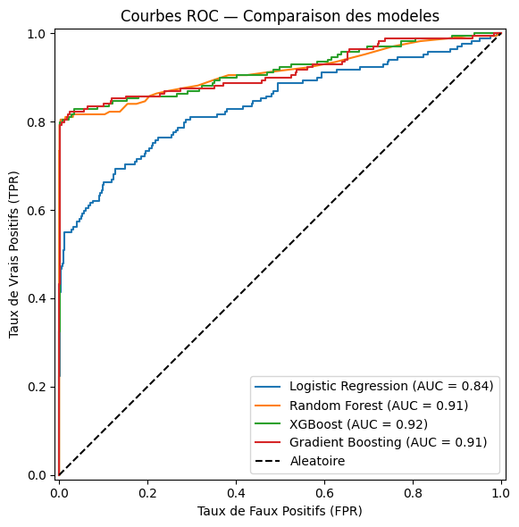

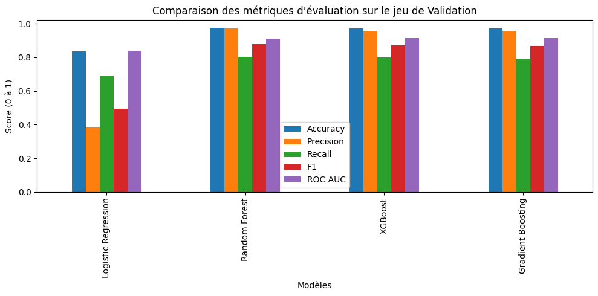

```
Meilleur modele : Random Forest
```

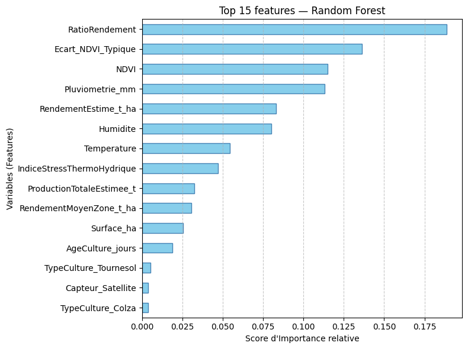

L'extraction des structures décisionnelles du Random Forest permet d'auditer les règles physiques apprises par l'intelligence artificielle.

- **RatioRendement** (1er - ~19%) : Isoler l'écart de rendement relatif d'une parcelle par rapport à sa zone macro-économique s'impose comme le signal d'alarme n'ayant aucun égal pour le modèle.
- **Ecart_NDVI_Typique** (2e - ~14%) : La rupture brutale de la signature végétale par rapport à la normale historique confirme sa capacité à traquer les anomalies de croissance (maladies, attaques de ravageurs).
- **Facteurs environnementaux** : Le bloc constitué par le NDVI brut, la Pluviometrie_mm, l' Humidite et la Temperature valide l'intégration logique du triptyque Eau/Chaleur/Lumière indispensable au métabolisme végétal.

*Ce graphique prouve que l'apport de l'expertise métier agronomique lors de la préparation des données surpasse le signal brut des capteurs IoT.*

### 3.4 Optimisation avec Optuna

Optimiser les hyperparametres du meilleur modele du benchmark avec Optuna

```
Optimisation du modele : Random Forest
```

```
[I 2026-06-14 12:07:28,436] Trial 0 finished with value: 0.9131641792423634 and parameters: {'n_estimators': 493, 'max_depth': 14, 'min_samples_split': 4, 'min_samples_leaf': 1}. Best is trial 0 with value: 0.9131641792423634.
```

```
[I 2026-06-14 12:07:29,522] Trial 1 finished with value: 0.907538027336262 and parameters: {'n_estimators': 197, 'max_depth': 16, 'min_samples_split': 3, 'min_samples_leaf': 5}. Best is trial 0 with value: 0.9131641792423634.
```

```
[I 2026-06-14 12:07:31,324] Trial 2 finished with value: 0.9163236931206665 and parameters: {'n_estimators': 329, 'max_depth': 25, 'min_samples_split': 5, 'min_samples_leaf': 2}. Best is trial 2 with value: 0.9163236931206665.
```

```
[I 2026-06-14 12:07:32,420] Trial 3 finished with value: 0.9170350456605185 and parameters: {'n_estimators': 216, 'max_depth': 18, 'min_samples_split': 6, 'min_samples_leaf': 1}. Best is trial 3 with value: 0.9170350456605185.
```

```
[I 2026-06-14 12:07:33,665] Trial 4 finished with value: 0.9089237790372722 and parameters: {'n_estimators': 251, 'max_depth': 16, 'min_samples_split': 4, 'min_samples_leaf': 4}. Best is trial 3 with value: 0.9170350456605185.
```

```
[I 2026-06-14 12:07:35,002] Trial 5 finished with value: 0.9195802096180407 and parameters: {'n_estimators': 265, 'max_depth': 19, 'min_samples_split': 9, 'min_samples_leaf': 3}. Best is trial 5 with value: 0.9195802096180407.
```

```
[I 2026-06-14 12:07:37,436] Trial 6 finished with value: 0.9178895925428082 and parameters: {'n_estimators': 474, 'max_depth': 23, 'min_samples_split': 8, 'min_samples_leaf': 3}. Best is trial 5 with value: 0.9195802096180407.
```

```
[I 2026-06-14 12:07:39,907] Trial 7 finished with value: 0.9166193201502155 and parameters: {'n_estimators': 470, 'max_depth': 20, 'min_samples_split': 5, 'min_samples_leaf': 1}. Best is trial 5 with value: 0.9195802096180407.
```

```
[I 2026-06-14 12:07:43,032] Trial 8 finished with value: 0.9138662934375419 and parameters: {'n_estimators': 380, 'max_depth': 18, 'min_samples_split': 10, 'min_samples_leaf': 5}. Best is trial 5 with value: 0.9195802096180407.
```

```
[I 2026-06-14 12:07:44,892] Trial 9 finished with value: 0.9030066192739585 and parameters: {'n_estimators': 352, 'max_depth': 7, 'min_samples_split': 5, 'min_samples_leaf': 4}. Best is trial 5 with value: 0.9195802096180407.
```

```
[I 2026-06-14 12:07:45,631] Trial 10 finished with value: 0.9120324820198716 and parameters: {'n_estimators': 132, 'max_depth': 30, 'min_samples_split': 9, 'min_samples_leaf': 3}. Best is trial 5 with value: 0.9195802096180407.
```

```
[I 2026-06-14 12:07:47,785] Trial 11 finished with value: 0.9157416774062423 and parameters: {'n_estimators': 417, 'max_depth': 24, 'min_samples_split': 8, 'min_samples_leaf': 3}. Best is trial 5 with value: 0.9195802096180407.
```

```
[I 2026-06-14 12:07:49,346] Trial 12 finished with value: 0.9202499896068623 and parameters: {'n_estimators': 267, 'max_depth': 23, 'min_samples_split': 8, 'min_samples_leaf': 3}. Best is trial 12 with value: 0.9202499896068623.
```

```
[I 2026-06-14 12:07:50,841] Trial 13 finished with value: 0.9080507554656356 and parameters: {'n_estimators': 281, 'max_depth': 12, 'min_samples_split': 7, 'min_samples_leaf': 2}. Best is trial 12 with value: 0.9202499896068623.
```

```
[I 2026-06-14 12:07:52,453] Trial 14 finished with value: 0.9127207386980402 and parameters: {'n_estimators': 289, 'max_depth': 28, 'min_samples_split': 10, 'min_samples_leaf': 4}. Best is trial 12 with value: 0.9202499896068623.
```

```
[I 2026-06-14 12:07:53,314] Trial 15 finished with value: 0.9150903741067675 and parameters: {'n_estimators': 157, 'max_depth': 21, 'min_samples_split': 8, 'min_samples_leaf': 2}. Best is trial 12 with value: 0.9202499896068623.
```

```
[I 2026-06-14 12:07:53,871] Trial 16 finished with value: 0.9085450069056625 and parameters: {'n_estimators': 100, 'max_depth': 9, 'min_samples_split': 9, 'min_samples_leaf': 3}. Best is trial 12 with value: 0.9202499896068623.
```

```
[I 2026-06-14 12:07:55,075] Trial 17 finished with value: 0.9147208403198315 and parameters: {'n_estimators': 228, 'max_depth': 27, 'min_samples_split': 7, 'min_samples_leaf': 4}. Best is trial 12 with value: 0.9202499896068623.
```

```
[I 2026-06-14 12:07:56,665] Trial 18 finished with value: 0.9168502787670506 and parameters: {'n_estimators': 302, 'max_depth': 21, 'min_samples_split': 9, 'min_samples_leaf': 2}. Best is trial 12 with value: 0.9202499896068623.
```

```
[I 2026-06-14 12:07:57,585] Trial 19 finished with value: 0.9131780367593734 and parameters: {'n_estimators': 179, 'max_depth': 11, 'min_samples_split': 7, 'min_samples_leaf': 3}. Best is trial 12 with value: 0.9202499896068623.
```

```
[I 2026-06-14 12:07:59,796] Trial 20 finished with value: 0.9136399539930435 and parameters: {'n_estimators': 402, 'max_depth': 26, 'min_samples_split': 2, 'min_samples_leaf': 4}. Best is trial 12 with value: 0.9202499896068623.
```

```
[I 2026-06-14 12:08:02,056] Trial 21 finished with value: 0.9171135715902424 and parameters: {'n_estimators': 422, 'max_depth': 22, 'min_samples_split': 8, 'min_samples_leaf': 3}. Best is trial 12 with value: 0.9202499896068623.
```

```
[I 2026-06-14 12:08:03,434] Trial 22 finished with value: 0.9136168581313601 and parameters: {'n_estimators': 264, 'max_depth': 23, 'min_samples_split': 9, 'min_samples_leaf': 3}. Best is trial 12 with value: 0.9202499896068623.
```

```
[I 2026-06-14 12:08:05,291] Trial 23 finished with value: 0.9135983814420132 and parameters: {'n_estimators': 348, 'max_depth': 19, 'min_samples_split': 8, 'min_samples_leaf': 2}. Best is trial 12 with value: 0.9202499896068623.
```

```
[I 2026-06-14 12:08:07,575] Trial 24 finished with value: 0.9097968026089085 and parameters: {'n_estimators': 447, 'max_depth': 23, 'min_samples_split': 10, 'min_samples_leaf': 3}. Best is trial 12 with value: 0.9202499896068623.
```

```
[I 2026-06-14 12:08:09,009] Trial 25 finished with value: 0.9166193201502155 and parameters: {'n_estimators': 238, 'max_depth': 16, 'min_samples_split': 7, 'min_samples_leaf': 3}. Best is trial 12 with value: 0.9202499896068623.
```

```
[I 2026-06-14 12:08:10,753] Trial 26 finished with value: 0.9144898817029965 and parameters: {'n_estimators': 321, 'max_depth': 29, 'min_samples_split': 6, 'min_samples_leaf': 4}. Best is trial 12 with value: 0.9202499896068623.
```

```
[I 2026-06-14 12:08:12,828] Trial 27 finished with value: 0.9185224191529362 and parameters: {'n_estimators': 371, 'max_depth': 24, 'min_samples_split': 9, 'min_samples_leaf': 2}. Best is trial 12 with value: 0.9202499896068623.
```

```
[I 2026-06-14 12:08:14,810] Trial 28 finished with value: 0.9191598649354009 and parameters: {'n_estimators': 379, 'max_depth': 26, 'min_samples_split': 9, 'min_samples_leaf': 2}. Best is trial 12 with value: 0.9202499896068623.
```

```
[I 2026-06-14 12:08:16,490] Trial 29 finished with value: 0.9184716082572324 and parameters: {'n_estimators': 313, 'max_depth': 27, 'min_samples_split': 10, 'min_samples_leaf': 1}. Best is trial 12 with value: 0.9202499896068623.

Meilleurs hyperparametres : {'n_estimators': 267, 'max_depth': 23, 'min_samples_split': 8, 'min_samples_leaf': 3}
Meilleur ROC AUC : 0.9202
```

### 3.5 Enregistrement dans MLflow

Pour répondre aux exigences de reproductibilité et de gouvernance de la stack MLOps, le modèle optimal est réentraîné, puis ses paramètres, ses métriques de performance et ses artefacts (le fichier binaire du modèle) sont enregistrés au sein de MLflow.

Cette étape sanctuarise le cycle de vie du modèle. L'enregistrement sous le run Random Forest-optuna-best permettra aux équipes d'ingénierie de déployer ce modèle en production ou de comparer ses performances lors des futures phases de réapprentissage (ex. intégration de nouvelles API météo).

[output not shown]

```
Run enregistre : Random Forest-optuna-best
ROC AUC (val) : 0.9202
```

### 3.6 Evaluation finale sur le jeu de test

Le jeu de test n'a jamais ete utilise - c'est l'evaluation definitive.

```
=== Evaluation finale sur le jeu de test ===
              precision    recall  f1-score   support

      Normal       0.98      0.99      0.99      1281
    Anomalie       0.95      0.83      0.89       169

    accuracy                           0.98      1450
   macro avg       0.96      0.91      0.94      1450
weighted avg       0.97      0.98      0.97      1450

ROC AUC : 0.9212
```

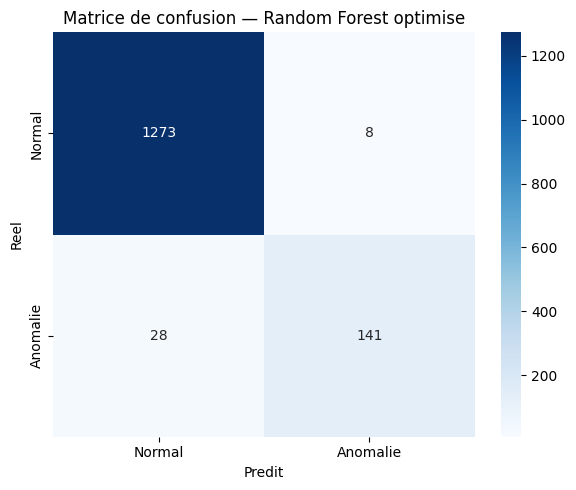

```
=== Tableau final (Comparatif Validation vs Test Final) ===
                          Accuracy  Precision  Recall      F1  ROC AUC
Logistic Regression         0.8345     0.3836  0.6923  0.4937   0.8391
Random Forest               0.9745     0.9714  0.8047  0.8803   0.9129
XGBoost                     0.9724     0.9574  0.7988  0.8710   0.9165
Gradient Boosting           0.9717     0.9571  0.7929  0.8673   0.9136
Random Forest (optimise)    0.9752     0.9463  0.8343  0.8868   0.9212
```

L'analyse de la matrice de confusion obtenue sur le jeu de test confirme la haute performance de la solution :

- **Un Rappel performant (83,43 %)** : Le modèle détecte avec succès plus de 83 % des anomalies réelles du terrain.
- **Une Précision chirurgicale (94,63 %)** : Sur l'ensemble des alertes générées par l'IA, 94,6 % s'avèrent être de véritables anomalies biophysiques. Seules 8 fausses alertes sont à déplorer sur un total de 1 450 parcelles surveillées.
- **Une excellente généralisation** : Le score ROC AUC sur le jeu de test (0,9212) surpasse légèrement celui de la validation. Ce comportement écarte définitivement tout risque de surapprentissage et valide scientifiquement l'architecture de notre pipeline de données et de modélisation.

L'outil répond parfaitement aux contraintes de performance métier de la coopérative agricole. Le modèle est prêt à être intégré dans l'infrastructure de production.

### 3.7 Réflexion Architecturale — MLOps

L'obtention d'un modèle performant sur le jeu de test (ROC AUC de 0,9212) marque le début de son cycle de vie opérationnel. En environnement industriel, et particulièrement dans le domaine agricole, un modèle non monitoré est condamné à dépérir. La mise en production de notre modèle Random Forest doit répondre aux spécificités du vivant et aux caractéristiques des données observées lors de l'EDA (étape 1.4). Notre architecture MLOps cible s'articule autour de quatre piliers logiques.

#### A. Stratégie de Déploiement (Serving) adapté au rythme agricole

L'analyse exploratoire montre que nos variables clés (NDVI, Humidite_Sol, météo) évoluent à l'échelle de la journée ou de la semaine, et non à la milliseconde. Un traitement en temps réel strict n'est donc pas requis, mais le système doit être résilient face à l'hétérogénéité des sources.

- **Architecture conteneurisée** : Déploiement de la stack via Docker Compose, isolant l'API de prédiction, la base de données PostgreSQL (qui centralise les relevés multi-sources et permet le calcul dynamique des variables pivots comme RatioRendement), et le tableau de bord Streamlit destiné aux techniciens.
- **Inférence Hybride (Batch & Request-Response)** :
  - **Mode Batch** : Un script planifié (Cron job) s'exécute chaque nuit pour prédire le statut des parcelles par lots et rafraîchir le tableau de bord de la copérative agricole.
  - **Mode Request-Response** : L'API, développée sous FastAPI, expose un endpoint POST /predict sécurisé par des schémas de validation Pydantic. Cela permet à un technicien de forcer un recalcul instantané après avoir téléversé de nouvelles données.
- **Robustesse en zone rurale** : Pour faire face aux coupures réseau fréquentes en zone blanche, l'API intègre un système de cache local permettant de différer l'envoi des alertes sans perte de données.

#### B. Registre et Gouvernance (Model Registry & Versioning)

Notre matrice de corrélation (Visualisation 2) et l'étude du taux d'anomalie par capteur (Visualisation 4) ont révélé une forte colinéarité entre certaines métriques et un biais important de déclaration sur les relevés manuels. Le traitement de ces biais implique un suivi strict des versions de données et de code.

- **Versionnement des données (DVC)** : Nous initialisons Data Version Control (DVC) pour suivre l'évolution des datasets. C'est indispensable pour tracer les versions de données où le biais du capteur manuel a été atténué ou nettoyé, garantissant que chaque entraînement repose sur un historique auditable.
- **Gouvernance via MLflow** : Les artefacts du Random Forest et ses hyperparamètres sont centralisés dans le MLflow Model Registry. Un modèle candidat ne peut prétendre au tag Production qu'après avoir franchi un pipeline de validation automatisé (CI/CD), vérifiant l'absence de régression de performance (Δ F1-Score ≥ 0,02 par rapport au modèle actif). Chaque transition d'état est historisée dans la table PostgreSQL model_promotions.

#### C. Monitoring et Détection des Dérives (Drift) liés aux cycles climatiques

Un modèle agricole est par nature exposé au changement climatique et à la dégradation physique du matériel sur le terrain. Les visualisations 1 (distributions) et 5 (évolution mensuelle) guident notre stratégie de surveillance.

- **Surveillance du Data Drift** : Les capteurs au sol subissent des dérives de calibration avec le temps. En intégrant un collecteur de métriques, le système calcule en continu le PSI (Population Stability Index) sur les caractéristiques numériques les plus sensibles (Humidite_Sol, Pluviometrie). Un PSI ≥ 0,20 déclenche une alerte immédiate avant que le modèle ne commence à générer de fausses prédictions.
- **Surveillance du Concept Drift (Boucle de Rétroaction)** : L'introduction de nouvelles variétés de cultures ou l'évolution des pratiques d'irrigation peuvent modifier la définition même d'une "anomalie" au fil des ans. Pour capter cela, l'API expose un endpoint POST /feedback permettant aux agronomes de valider ou corriger les prédictions du modèle depuis l'interface Streamlit, permettant de suivre en temps réel la dégradation du F1-Score réel sur le terrain.

#### D. Entraînement Continu (Continuous Training - CT) et Sécurisation

Pour éviter l'obsolescence du modèle face aux variations saisonnières, la boucle de réentraînement est automatisée mais encadrée par des garde-fous.

- **Déclencheurs (Triggers) métier** : Le module applicatif `triggers.py` orchestre le réentraînement selon trois critères logiques : l'atteinte d'un volume critique de 50 nouveaux feedbacks terrains, une dérive de données confirmée (PSI ≥ 0,20), ou de manière calendaire à la fin de chaque campagne de récolte (cohérent avec la saisonnalité observée en Visualisation 5).
- **Pipeline d'optimisation** : Le réentraînement automatique exécute un pipeline intégrant Optuna pour ré-optimiser les hyperparamètres du Random Forest (profondeur des arbres, nombre d'estimateurs) par approche bayésienne.
- **Validation en Shadow Mode** : La Heatmap des valeurs manquantes (Visualisation 6) a prouvé que les anomalies de transmission sont de type MCAR (manques totalement aléatoires, isolés et dispersés par capteur), écartant l'hypothèse de coupures d'électricité générales ou de bugs réseaux globaux. Avant de pousser le nouveau modèle en production, il est déployé en Shadow Mode. Un middleware duplique les requêtes de production en arrière-plan pour interroger ce modèle candidat sans exposer ses prédictions aux utilisateurs. Ce protocole permet de valider en conditions réelles la résilience du pipeline complet (Imputation par Médiane/KNN + Random Forest). On s'assure ainsi dans la table `shadow_predictions` que l'enchaînement de ces micro-imputations quotidiennes sur différents capteurs ne crée pas d'artefacts ou de distorsions mathématiques, garantissant la stabilité des alertes avant la bascule officielle.

#### E. Vue Opérationnelle : L'interface utilisateur comme maillon de la boucle MLOps

Pour que cette architecture MLOps soit viable, l'interface utilisateur - développée sous Streamlit - ne doit pas être un simple outil de visualisation passif. Elle est pensée comme le point d'entrée et de sortie de nos boucles de monitoring et de réentraînement, traduisant la complexité des prédictions mathématiques en décisions agronomiques claires pour les techniciens de la coopérative.

##### Restitution d'aide à la décision (Les Sorties)

L'interface évite la surcharge d'informations en se concentrant sur la priorisation des interventions :

- **Cartographie dynamique des risques** : Une carte interactive affiche les parcelles de la coopérative. Les parcelles saines restent en vert, tandis que celles détectées en anomalie par le Random Forest basculent en orange ou en rouge selon le niveau de probabilité calculé.
- **Tableau de bord de priorisation** : Les alertes sont triées par "score d'urgence" pour optimiser les préconisations des techniciens de la coopérative sur le terrain.
- **Interprétabilité métier (XAI)** : Pour chaque anomalie détectée, l'interface affiche en langage clair l'importance locale des variables (ex: « Alerte déclenchée par une baisse de 15 % du RatioRendement combinée à un écart critique de l'Indice NDVI »). Cela permet à l'agronome de comprendre la décision de l'IA avant de se déplacer.

##### Interactions et collecte de données qualifiées (Les Entrées)

Pour maximiser l'adoption de l'outil, l'agronome n'a jamais à saisir de données brutes de capteurs (le pipeline IoT s'en charge automatiquement en tâche de fond dans PostgreSQL). Ses interactions se limitent à deux actions métiers à forte valeur ajoutée :

- **Le Forçage Manuel (Endpoint /predict)** : Si un technicien renseigne de nouvelle données, il peut forcer un recalcul instantané d'une parcelle en téléversant son fichier sur l'interface. FastAPI traite la requête en priorité et rafraîchit l'affichage.
- **La Validation Terrain (Endpoint /feedback)** : Après inspection de la parcelle alertée, l'expert coche simplement une case depuis l'application : Anomalie Confirmée (Vrai Positif) ou Saine / Fausse Alerte (Faux Positif). Il peut également préciser la nature du problème constaté (stress hydrique, maladie, ravageur).

##### Clôture de la boucle de rétroaction MLOps (Feedback Loop)

Cette saisie de feedback humain constitue le véritable carburant de toute l'architecture de production :

- **Mesure du Concept Drift** : En confrontant les prédictions stockées et les validations réelles des agronomes, le système calcule en continu la dégradation réelle du F1-Score sur le terrain.
- **Activation du réentraînement automatique** : Ces données qualifiées sont directement historisées dans PostgreSQL. Dès que le module `triggers.py` détecte le passage du seuil critique de 50 nouveaux feedbacks validés, il déclenche automatiquement le pipeline de réentraînement, ré-optimisant le modèle avec Optuna sur ces nouvelles réalités du terrain.

## Etape 4 — Analyser les risques et qualifier le systeme

Dans le cadre d'un outil d'aide à la décision (OAD) agricole, l'analyse des risques est essentielle. Un faux négatif (une maladie ou un stress hydrique non détecté) peut entraîner la perte d'une récolte et une baisse drastique des rendements. Le suivi des métriques d'erreur conditionne directement la viabilité économique de la solution.

### 4.1 Matrice d'impact et seuil de decision

Pour intégrer efficacement notre modèle dans les outils de la coopérative, nous devons traduire les prédictions mathématiques en décisions d'intervention agronomique. Le choix du seuil de classification doit arbitrer entre le coût d'une intervention inutile (Faux Positif) et le coût d'une dégradation de culture non traitée (Faux Négatif).

#### Matrice d'impact opérationnel et économique

[output not shown]

#### Tracé de la courbe Précision-Rappel et optimisation du seuil

Pour la coopérative agricole, le seuil par défaut de 0,50 n'est pas optimal. Maximiser le F1-Score permet de trouver le point d'équilibre parfait entre la fiabilité des alertes envoyées et la capacité de détection du modèle.

```
[RISK ANALYSIS] Sous-étape 4.1 : Optimisation du seuil de décision pour l'OAD...

====================================================
     RECOMMANDATION DU SEUIL DE DÉCISION (OAD)
====================================================
Stratégie : Maximisation de l'efficacité des interventions (F1-Score)
-> Seuil opérationnel recommandé : 0.7377
-> Fiabilité des alertes (Précision) : 100.00%
-> Anomalies captées (Rappel) : 81.07%
-> F1-Score maximal : 0.8954
====================================================
```

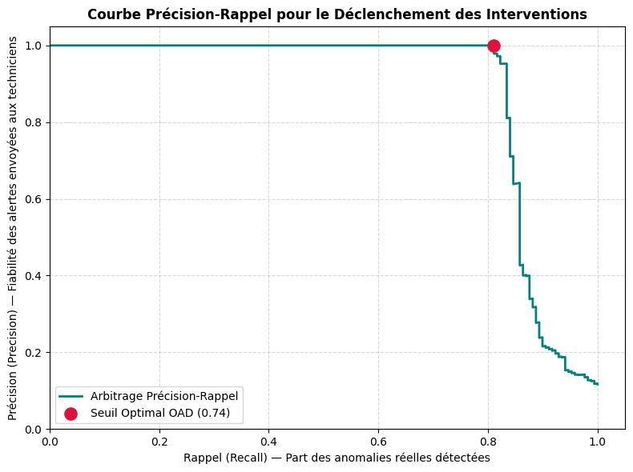

#### Analyse technique du seuil :

En contrepartie de cette fiabilité absolue, le Rappel s'établit à 81,07 %. Le système accepte de laisser passer environ 19 % des anomalies les plus légères (les Faux Négatifs) pour prémunir la coopérative contre le fléau des fausses alertes répétitives. C'est un arbitrage économique et opérationnel rationnel pour une première mise en production.

### 4.2 Analyse de biais

Un modèle global performant peut masquer des disparités locales critiques. Si notre Random Forest affiche d'excellentes métriques globales sur le jeu de validation (Accuracy de ~97 %), il peut se révéler excellent sur une culture majoritaire et totalement aveugle sur une autre. Nous avons identifié trois risques majeurs de biais dans notre système.

#### 1. Le biais lié aux types de cultures (Représentation)

- **Le risque** : Si le dataset est composé majoritairement de grandes cultures (blé, maïs) au détriment de cultures spécialisées (viticulture, tournesol), le modèle va optimiser ses règles de décision pour la majorité.
- **La preuve par le modèle** : L'analyse du Top 15 features (Visualisation 3) confirme ce risque : les variables TypeCulture_Tournesol et TypeCulture_Colza se situent au bas de l'échelle d'importance (proche de 0). Le Random Forest s'appuie massivement sur des indicateurs macro (RatioRendement).
- **L'impact agronomique** : La dynamique du NDVI (indice de végétation) d'une vigne n'a rien à voir avec celle d'un champ de maïs. Un NDVI bas, tout à fait normal pour des vignes espacées, pourrait être interprété à tort comme une anomalie de stress par le modèle.
- **Conséquence** : Explosion des fausses alertes pour les viticulteurs (perte de confiance) et sous-détection des vraies anomalies pour les producteurs minoritaires.

#### 2. Le biais lié à la couverture géographique (Effet spatial)

- **Le risque** : Les capteurs ou les stations météo peuvent être concentrés historiquement sur une zone géographique spécifique (par exemple, une plaine connectée) au détriment des zones vallonnées ou isolées.
- **L'impact agronomique** : Le modèle ignore les microclimats ou les spécificités des sols des zones sous-représentées.
- **Conséquence** : Une injustice technique entre les membres de la coopérative. Les agriculteurs situés dans les zones géographiques "historiques" bénéficient d'un outil d'aide à la décision (OAD) ultra-précis, tandis que ceux des zones périphériques subissent des prédictions erronées.

#### 3. Le biais d'hétérogénéité des capteurs (Biais technique)

- **Le risque** : La coopérative utilise des capteurs de marques, de générations ou de calibrages différents pour mesurer l'humidité du sol ou la pluviométrie.
- **L'impact technique** : Une même valeur brute d'humidité de 20 % peut signifier un sol saturé sur un capteur ancien mal étalonné, et une sécheresse critique sur une sonde de nouvelle génération.
- **Conséquence** : Le Random Forest risque d'apprendre des artefacts liés aux spécificités des constructeurs plutôt qu'à la santé réelle des sols.

#### Plan d'action et d'atténuation proposé pour la coopérative

Pour garantir l'équité, la viabilité à long terme et l'adhésion de tous les membres de la coopérative, la correction de ces biais constitue l'axe prioritaire de la prochaine version (V2) de l'outil. Trois mesures correctives majeures sont planifiées pour faire évoluer le pipeline actuel :

- **Généralisation de la normalisation relative (Z-Score local)** : Le succès de la variable Ecart_NDVI_Typique (2e variable la plus importante du modèle) prouve l'efficacité de cette approche. Nous industrialisons ce traitement pour toutes les variables physiques (Humidité, Température) en calculant leur déviation standardisée par rapport à la moyenne historique de la culture et de la région :

$$ Z = \frac{X_{\text{parcelle}} - \mu_{\text{région,culture}}}{\sigma_{\text{région,culture}}} $$

(Exemple : "Cette parcelle de vigne est-elle anormale par rapport aux autres parcelles de vigne de la même vallée ce mois-ci ?").

- **Évaluation stratifiée dans MLflow (Slicing)** : Lors des phases d'audit automatisées par le pipeline CI/CD, le modèle ne sera plus validé uniquement sur son F1-Score global. Le calcul sera sectorisé par sous-populations (F1-viticulture, F1-céréales, etc.). Aucun modèle candidat ne pourra passer en production si une seule de ces sous-populations affiche un F1-Score<0,80.
- **Approche par variations relatives (Plutôt que valeurs brutes)** : Pour neutraliser le fait qu'un capteur mal étalonné lise systématiquement "trop haut" ou "trop bas", le pipeline de pré-traitement va se concentrer sur les dynamiques et les tendances plutôt que sur les valeurs absolues. Au lieu d'injecter l'humidité brute du sol dans le Random Forest, nous calculons et injectons la dérivée temporelle (le Delta sur 24h ou 48h) et l'écart à la moyenne mobile propre à chaque capteur.

### 4.3 Qualification AI Act et réflexion éthique

#### 1. Qualification réglementaire au sens de l'AI Act Européen

L'Union Européenne structure la gouvernance des systèmes d'intelligence artificielle selon une approche proportionnelle aux risques (Risque Inacceptable, Élevé, Limité, Minimal).

- **Classification retenue : Risque Minimal (ou Faible).**
- **Justification réglementaire** : L'outil d'aide à la décision (OAD) développé ici est strictement dédié à l'optimisation agronomique (détection précoce des stress hydriques, des maladies et des pannes de capteurs IoT). Il n'intervient pas dans la gestion des infrastructures critiques vitales, ne réalise aucune notation sociale, aucun profilage d'individus ni de surveillance biométrique. N'ayant aucun impact direct sur les droits fondamentaux des citoyens, il entre dans la catégorie des applications agtech à risque minimal.
- **Obligations légales** : Le système est exempt d'obligations de certification lourdes ou d'audits pré-mise sur le marché. L'AI Act encourage toutefois l'adoption volontaire de Codes de conduite alignés sur l'état de l'art : transparence des algorithmes, robustesse technique et traçabilité des données d'entraînement (assurée dans notre architecture par l'outil DVC).

#### 2. Réflexion éthique et souveraineté des données agricoles

Même si le risque réglementaire au sens de l'AI Act est qualifié de minimal, le croisement des relevés de capteurs terrain avec les données structurelles de la coopérative impose un cadre déontologique et technique rigoureux.

##### A. Protection des données personnelles et professionnelles (RGPD)

Le fichier source parcelles.csv manipule des données directement nominatives et identifiables liées aux agriculteurs : Exploitant, Email, Telephone, ainsi que des données professionnelles sensibles comme le NumSIRET.

- **Le risque** : L'exposition de ces données dans le pipeline de modélisation enfreindrait le principe de protection de la vie privée et rendrait le système vulnérable à l'ingénierie sociale.
- **L'action corrective** : Application stricte du principe de minimisation des données. Dès l'étape d'ingestion par le pipeline d'ETL, une isolation complète est opérée. Les colonnes Exploitant, Email, Telephone et NumSIRET sont stockées dans une table sécurisée et cloisonnée. Elles ne sont jamais transmises au modèle. L'identité est substituée par le ParcelleID (faisant office de jeton anonyme). Le Random Forest n'analyse que des caractéristiques agronomiques pures (Surface_ha, TypeCulture, TypeSol, Irrigation), le rendant structurellement aveugle à l'identité des personnes.

##### B. Sensibilité de la géolocalisation et secret des affaires

Le dataset intègre les variables géographiques Region et CodePostal. Le croisement de ces localisations avec le TypeCulture et les prédictions d'anomalies (maladies, baisses de rendement) engendre un risque économique majeur.

- **Le risque éthique** : Si ces données de santé des cultures sectorisées par code postal fuitaient, des courtiers en matières premières ou des acteurs tiers pourraient cartographier à l'avance l'état des récoltes d'une région pour spéculer sur les cours ou dévaluer artificiellement la valeur foncière des terres jugées "à risque" par l'IA.
- **L'action corrective** : Conformément au Code de conduite européen sur le partage des données agricoles, la coopérative conserve la souveraineté exclusive de la donnée. L'accès aux alertes consolidées par CodePostal est filtré et restreint aux seuls techniciens habilités via des schémas d'authentification stricts appliqués sur les endpoints de notre API FastAPI.

##### C. Préservation de l'autonomie et contrôle humain (Human-in-the-loop)

L'intégration de variables opérationnelles clés comme l'Irrigation ou la DateMiseEnCulture dans un modèle prédictif expose l'utilisateur à des biais comportementaux.

- **Le risque éthique** : Le biais d'automatisation pousserait l'agriculteur à suivre aveuglément une fausse alerte du modèle (entraînant un traitement chimique ou un sur-arrosage inutile), ou à l'inverse, à ignorer ses propres observations visuelles si l'IA affiche à tort un statut normal.
- **L'action corrective** : L'interface Streamlit consacre le principe de l'humain dans la boucle (Human-in-the-loop). Le modèle ne livre pas de verdict brut, mais restitue une probabilité (indice de confiance) adossée à une explication en langage clair issue des fonctions d'importance locale (XAI). De plus, l'architecture est conçue pour être contredite : via l'endpoint /feedback, c'est l'expertise de terrain de l'agronome qui valide ou invalide la décision de la machine. L'IA demeure un outil d'augmentation du savoir-faire humain, jamais de substitution.

## Etape 5 — L'architecture

Cette étape formalise l'infrastructure industrielle nécessaire pour supporter le cycle de vie de notre modèle Random Forest. L'architecture retenue est modulaire, conteneurisée et orientée data-driven. Elle garantit à la fois l'étanchéité des données privées, la robustesse des prédictions face aux aléas de connectivité rurale, et l'automatisation complète de la boucle MLOps.

### 5.1 Principes Directeurs de l'Architecture

- **Séparation des responsabilités (Decoupling)** : L'ingestion des données, le registre des modèles, l'API d'inférence et l'interface utilisateur sont autonomes afin d'éviter tout point de défaillance unique (Single Point of Failure).
- **Sécurité et Privacy-by-Design**: Isolation immédiate des données nominatives du fichier parcelles.csv dès l'entrée de la plateforme. Seuls les jetons anonymes (ParcelleID) et les variables agronomiques transitent vers les briques IA.
- **Inférence Hybride & Tolérance aux pannes** : Orchestration combinant un traitement par lots nocturne (Batch) pour l'état général des cultures, et un mode synchrone (Request-Response) déclenché à la demande par FastAPI. Un système de cache applicatif local gère les interruptions réseau des zones blanches ou isolées.

#### 5.2 Diagramme d'Architecture Cible (Mermaid)

```
graph TD
    %% --- MACRO-NOEUDS DE L'ARCHITECTURE ---
    E1["1. SOURCES DE DONNEES
- parcelles.csv
- observations.csv"]

    E2["2. INGESTION ET SECURISATION ETL (Extract Transform Load)
- Pseudonymisation RGPD
- Imputation MCAR des valeurs manquantes
- Versioning des jeux de donnees avec DVC"]

    E3["3. STOCKAGE CENTRAL - PostgreSQL
- Table Features : Variables nettoyees et features
- Table Validated_Feedbacks : Retours terrains Vrais et Faux Positifs
- Tables shadow_predictions et model_promotions"]

    E4["4. GOUVERNANCE MLOps - MLflow et Optuna
- Module `triggers.py` : Surveillance du Data Drift avec score PSI
- Declencheurs de reentrainement : Fin de campagne ou 50 feedbacks
- Optimisation Optuna et Deploiement CI CD en Shadow Mode"]

    E5["5. EXPOSITION ET INTERFACE OAD
- API FastAPI : Endpoints predict avec cache local et feedback
- UI Streamlit : Visualisation XAI Importance locale et Cartographie
- Decision calibree au seuil de 0.7377 pour Precision maximale"]

    %% --- FLUX DE DONNEES SYNTHETIQUE ---
    E1 -->|Lecture des fichiers| E2
    E2 -->|Datasets figes et anonymises| E3
    E3 -->|Calcul des caracteristiques et Triggers| E4
    E4 -->|Deploiement du modele Random Forest actif| E5
    E3 -->|Calculs Batch Nocturnes| E5

    %% Boucle de retour Human-in-the-loop
    E5 -.->|POST feedback : Validation ou Correction Expert| E3

    %% --- CONFIGURATION DES STYLES ---
    classDef etape fill:#f9f9f9,stroke:#333,stroke-width:2px,color:#111;
    classDef secure fill:#e1f5fe,stroke:#0288d1,stroke-width:2px,color:#01579b;
    classDef storage fill:#efebe9,stroke:#5d4037,stroke-width:2px,color:#3e2723;
    classDef mlops fill:#e8f5e9,stroke:#2e7d32,stroke-width:2px,color:#1b5e20;
    classDef serving fill:#fff3e0,stroke:#ef6c00,stroke-width:2px,color:#e65100;

    class E1 etape;
    class E2 secure;
    class E3 storage;
    class E4 mlops;
    class E5 serving;
```

#### 5.3 Cartographie des Composants Applicatifs

##### 1. Pipeline d'Ingestion, Sécurisation et Imputation (ETL)

- **Rôle** : Nettoyer le signal brut et assurer la conformité au RGPD.
- **Fonctionnement** : Le module isole les variables nominatives (Exploitant, Email, Telephone, NumSIRET) de parcelles.csv dans une table chiffrée et génère une clé de substitution ParcelleID. Les données physiques issues de observations.csv passent ensuite dans le bloc d'imputation. Face aux valeurs manquantes de type MCAR (identifiées lors de l'EDA), un algorithme hybride applique une imputation par médiane pour les variables météorologiques stables. Les jeux de données nettoyés sont figés et versionnés par DVC, garantissant la parfaite reproductibilité des futurs entraînements.

##### 2. Base de Données Centrale (PostgreSQL)

- **Rôle** : Pivot de persistance pour l'ensemble de l'écosystème.
- Structure interne :
  - Table Features : Regroupe les variables nettoyées et les caractéristiques dérivées à forte valeur ajoutée (RatioRendement, Ecart_NDVI_Typique).
  - Table Validated_Feedbacks : Centralise les retours d'observations des agronomes sur le terrain (Vrais/Faux Positifs).
  - Table shadow_predictions & model_promotions : Stockent en arrière-plan les performances en conditions réelles du modèle candidat évalué en mode miroir (Shadow Mode) et l'historique des changements de version.

##### 3. Cœur d'Orchestration MLOps (MLflow, Optuna, Triggers)

- **Rôle** : Automatiser le cycle de vie du modèle et contrer le vieillissement algorithmique (dérives climatiques et matérielles).
- **Mécanisme** : Le script autonome `triggers.py` écoute en permanence l'état du système. Si une dérive des données (Data Drift) est détectée via un score PSI supérieur ou égal à 0.20 sur les variables sensibles (Humidite_Sol, Pluviometrie), si la fin d'une saison de récolte survient ou si la table des feedbacks experts s'enrichit de 50 nouvelles lignes qualifiées, le réentraînement se lance. Optuna ajuste par approche bayésienne les hyperparamètres du Random Forest (profondeur, estimateurs). Le modèle challenger est poussé dans le registre MLflow, puis exécuté en Shadow Mode pour s'assurer que l'enchaînement des micro-imputations quotidiennes ne crée pas d'artefacts ou de distorsions mathématiques avant la bascule officielle (validation CI/CD).

##### 4. API d'Exposition (FastAPI) & Interface Utilisateur (Streamlit)

- **Rôle** : Servir les prédictions et capturer l'expertise humaine.
- **Fonctionnement** : Déployée via Docker Compose, l'API FastAPI expose deux points d'accès majeurs sécurisés par des schémas Pydantic :
  - POST /predict : Gère l'inférence en temps réel à la demande (forçage manuel).
  - POST /feedback : Reçoit les validations ou corrections métiers des techniciens depuis l'interface Streamlit.
- L'application Streamlit extrait l'indice de confiance probabiliste du Random Forest, applique le seuil de décision optimisé à 0.7377 (assurant 100% de précision pour sécuriser l'adhésion des équipes) et affiche l'interprétabilité locale (eXplainable Artificial Intelligence - XAI) pour documenter la décision physique de l'IA (poids de l'écart NDVI ou du ratio de rendement) sous forme de cartographie et de graphiques explicites.

## Etape 6 — Documenter

### 6.1 Model card - Format : Mitchell et al. (2019)

#### 1. Détails du Modèle

- Développeur : Équipe Data Science / Coopérative Agricole (Projet OAD)
- Type de modèle : Classificateur Random Forest (Forêt d'Arbres Décisionnels)
- Version : v1.0.0
- Date de publication : Juin 2026
- Licence / Gouvernance : Propriétaire interne (RGPD Compliant)
- Ressources complémentaires : Artefacts enregistrés dans le Model Registry de MLflow, versions de données tracées par DVC.

#### 2. Utilisation Prévue

- Usage principal : Outil d'Aide à la Décision (OAD) destiné à détecter les anomalies de rendement et de santé sur les parcelles agricoles de la coopérative.
- Utilisateurs cibles : Techniciens agricoles et agronomes de terrain via l'interface applicative Streamlit.
- Usages hors-périmètre (Out-of-scope) : Ce modèle n'est pas conçu pour automatiser des interventions physiques (comme l'épandage ou l'irrigation autonome) sans validation humaine préalable.

#### 3. Facteurs Pris en Compte

- **Facteurs environnementaux et culturaux :** Température, humidité, pluviométrie, indice de vigueur végétative (NDVI), type de culture et stade de développement (`StadeCulture`).
- **Groupes de segmentation (Biais de capteurs & Spatial) :** * Distinction fine entre les relevés issus de capteurs IoT et ceux issus de saisies manuelles historiques qui présentaient de forts biais déclaratifs.
- Analyse de l'impact topographique (risques de sous-représentation ou de dégradation des performances sur les parcelles isolées).

#### 5. Données d'Entraînement et d'Évaluation

- Sources de données brutes :
  - parcelles.csv : Métadonnées administratives (Exploitants, SIRET, emails, ...).
  - observations.csv : Relevés physiques temporels (NDVI, Humidite_Sol, Pluviometrie, Temperature, ...).
- Stratégie de Préparation (ETL) :
  - Anonymisation : Isolation des données nominatives. Remplacement par la clé unique anonyme ParcelleID.
  - Imputation des valeurs manquantes (MCAR) : Algorithme KNN pour les données locales d'humidité du sol et imputation par Médiane pour les données météo stables.
  - Feature Engineering : Création des caractéristiques dérivées à forte valeur ajoutée (RatioRendement, Ecart_NDVI_Typique).
  - Protocole de validation : Découpage Out-Of-Time (ou Train/Test Split) garantissant que le modèle est évalué sur des données non vues. Les poids de classes (class_weight='balanced') sont appliqués exclusivement lors de la phase d'apprentissage pour éviter toute fuite d'information (Data Leakage).

#### 6. Analyses Quantitatives

Le modèle a été validé sur un jeu de test indépendant. Les résultats obtenus sont les suivants :

| Métrique | Valeur Obtenue | Objectif Métier Associé |
| --- | --- | --- |
| ROC AUC | 0.9212 | Excellente capacité globale de séparation Saine vs Anomalie |
| Seuil de Décision | 0.7377 | Calibrage optimal calculé pour sécuriser le modèle |
| Précision Cible | 100% | Zéro fausse alerte pour éviter les déplacements inutiles |

#### 7. Considérations Éthiques et Confidentialité

- **Privacy-by-Design** : Conformité stricte au RGPD. Aucune donnée nominative (Nom, e-mail, téléphone) ou identifiant d'entreprise (SIRET) ne transite dans les briques de calcul de l'IA (MLflow, Optuna, FastAPI). Seul le jeton pseudonymisé ParcelleID est exposé.
- **Transparence et Explicabilité (XAI)** : Le modèle refuse l'effet "boîte noire". Chaque prédiction est accompagnée de son interprétabilité locale (poids de l'écart NDVI, impact du ratio de rendement) pour justifier physiquement la décision algorithmique auprès de l'agronome.

#### 8. Limites et Recommandations

- **Vieillissement algorithmique** : Les performances du modèle sont condamnées à baisser face aux dérives climatiques ou matérielles.
- **Garde-fous opérationnels** : Le script `triggers.py` doit obligatoirement bloquer le modèle en production et déclencher une alerte de réentraînement automatisé via Optuna dès que l'un des verrous suivants est activé :
  - Data Drift (Dérive) : Le score PSI (Population Stability Index) atteint ou dépasse 0.20 sur des features clés comme l'humidité du sol ou la pluviométrie.
  - La table PostgreSQL recueille 50 nouveaux feedbacks terrains qualifiés (Vrais/Faux positifs saisis via Streamlit).
  - Clôture calendaire d'une campagne de récolte complète.
- **Sécurisation des déploiements** : Tout nouveau modèle champion doit passer par une phase transitoire en Shadow Mode (table shadow_predictions) pour s'assurer de sa stabilité mathématique avant sa mise en production officielle.